# Final_Project

## *Manuel Ritter - Final Project: Inventory Calculator with Python*

Verwendete Pakete:

```python
import pandas as pd
import numpy as np
from IPython.display import Image
from matplotlib import pyplot as plt
import seaborn as sns
```

## 1. PERI Geschäftsmodell

Die Firma PERI ist ein global agierendes Unternehmen des süddeutschen Mittelstandes. PERI produziert im schwäbischen Weißenhorn Schalungen und Gerüste für die Baubranche. Dabei verkauft PERI die Erzeugnisse im ersten Schritt an seine rund 60 Tochtergesellschaften weltweit. Im folgenden Schritt halten die Tochtergesellschaften die Produkte zunächst auf Lager vorrätig und verkaufen die Artikel bei Vertragsabschluss an dessen Baukunden.

Dieses Geschäftsmodell ist für PERI sehr kapitalintensiv: Je nach Bewertungsansatz (Bezugspreis vs. Listenpreis) liegt in Summe bei PERI in den erwähnten 60 Tochtergesellschaften weltweit ein 3-stelliger Millionen- oder gar Milliardenbetrag auf Lager.

## 1.1 Vision: Standardisiertes Demand Planning @ PERI

Zum heutigen Zeitpunkt ist in den Tochtergesellschaften keine einheitliche, datengetriebene Demand-Planning-Software verfügbar.

Die operativen Mitarbeiter in den Demand-Planning-Bereichen der Tochtergesellschaften arbeiten heute je nach Tochtergesellschaft mit unterschiedlichen Methoden:

- sie vertrauen auf Bedarfsprognosen des Vertriebs
- sie arbeiten mit ihren eigenen nicht standardisierten (Excel-)Lösungen
- sie bestellen basierend auf Erfahrungswerte vergangener Jahre

Langfristiges Ziel über das hier bearbeitete Projekt hinaus ist es, über eine Schnittstelle (API) bestimmte Daten zur Bedarfsplanung aus den ERP-Systemen der Tochtergesellschaften abzugreifen. Die benötigten Daten wären:

- Stammdaten (Artikel, Produktgruppe, Preise)
- Lagerbestände (historisch sowie aktuell)
- Lagerbewegungen (Zugänge, Abgänge)

Da eine Schnittstelle den Umfang des Projektes übersteigt, wird im Folgenden ein den Anforderungen entsprechender Datensatz der PERI Tochter aus Norwegen eingelesen und dieser verarbeitet.

## 1.2 Mission: Datenberechnungen und - visualisierungen

**Datenberechnungen:** Um die Lagerbestände in den Tochtergesellschaften zu optimieren und zukünftig zum richtigen Zeitpunkt Bestellungen auszulösen, soll die Historie der Artikel aufgearbeitet werden.

Dabei werden die Daten der historischer Verkaufsmengen herangezogen, um zunächst geglättete Nachfragemengen abzuleiten. Schließlich werden daraus resultierende optimale Lagermengen berechnet.

Diese werden im dritten Schritt mit den aktuellen Lagerbeständen verglichen und vorhandene Über-/ bzw. Unterkapazitäten identifiziert.

Gleichzeitig sollen auf Artikelebene aktuelle Produktions- und Transportlieferzeiten durch einen Algorithmus berücksichtigt werden.

**Datenvisualisierungen:** Im zweiten Teil des Projekts sollen

- Artikel priorisiert (durch Sortierung nach bestimmten KPIs) und
- die errechneten Optimalmengen grafisch mit den aktuellen Bestandsmengen verglichen werden.

Die Visualisierungen sollen je nach Betrachtungsperspektive auf Artikelebene, auf Produktgruppenebene (Aggregation der Artikel) oder auf Gesamtportfolioebene dargestellt werden.

## 2. Quelldatensätze einlesen und aufbereiten

Das analytical Dataset (= Hauptdatensatz) wird im folgenden Code unter der Bezeichnung "Source" eingelesen. Dieser Arbeitsschritt könnte bei Integration des Inventory Calculators ins produktive PERI-Geschäft durch eine API an die bestehenden SAP Systeme ersetzt werden.

```python
Source=pd.read_csv("181231_INVENTORY_CALCULATOR_SOURCE_1100.csv",sep=";", encoding="iso8859_15")

print("Number of Rows: \t" + str(Source.shape[0]))
print("Number of Columns: \t" + str(len(Source.columns)))
print("-"*35)
print(Source.columns.values)
```

```
Number of Rows: 	35328
Number of Columns: 	28
-----------------------------------
['PSD_FA' 'STOCKYARD' 'CALMONTH' 'RANG' 'ARTICLE' 'ARTICLE_TXT' 'PG'
 'PG_TXT' 'REVENUE_FLAG' 'BASE_UOM' 'PRICE_UNIT' 'HPC_PER_ARTICLE_EUR'
 'NBV_PER_ARTICLE_EUR' 'LPT_PER_ARTICLE_EUR' 'LP1_PER_ARTICLE_EUR'
 'HPC_TOTAL_ON_STOCK_EUR' 'NBV_TOTAL_ON_STOCK_EUR'
 'LPT_TOTAL_ON_STOCK_EUR' 'LP1_TOTAL_ON_STOCK_EUR' 'DISPOSALS_SALES'
 'DISPOSALS_RENTAL_PARK' 'DISPOSALS_S2S' 'DISPOSALS_OTHERS'
 'ADDITIONS_S2S' 'ADDITIONS_OTHERS' 'QTYSTOCK_LAST_DAY' 'TURNOVER_EUR'
 'NUMBER_OF_MAINORDERS']
```

Wie aus obigem Code zu entnehmen ist, beinhaltet der Datensatz 35.328 Datenzeilen und 28 Datenspalten.

Hinter den 28 Spalten verbergen sich folgende Informationen:

Stammdaten:

- PSD_FA: Landesnummer (Primary Key des PERI ERP-Systems)
- STOCKYARD: Lagernummer (sollte ein Land mehr als 1 Lagerstandort haben)
- CALMONTH: Monat (der Kennzahlen aus der jeweiligen Datenzeile, der Datensatz beinhaltet die letzten 24 Monate)
- RANG: Rang (der Kennzahlen aus der jeweiligen Datenzeile, diese Spalte ist wichtig da sich der Rang im Gegensatz zum Monat nicht ändert)
- ARTICLE: Artikelnummer des Artikels der jeweiligen Datenzeile
- ARTICLE_TXT: Artikelbezeichnung des Artikels der jeweiligen Datenzeile
- PG: Produkgruppennummer, welche diesem Artikel zugeordnet ist
- PG_TXT: Produktgruppentext, welcher diesem Artikel zugeordnet ist
- REVENUE_FLAG: Erlöskennzeichen, für dieses Projekt nicht relevant (könnte bei weiteren Analysen relevant werden)
- BASE_UOM: Basismengeneinheit, für dieses Projekt nicht relevant (könnte bei weiteren Analysen relevant werden)
- PRICE_UNIT: Preiseinheit, für dieses Projekt nicht relevant (könnte bei weiteren Analysen relevant werden)

Preise:

- HPC_PER_ARTICLE_EUR: AHK-Preis pro Artikel (inkl. Zölle und Steuern)
- NBV_PER_ARTICLE_EUR: Nettobuchwert pro Artikel (inkl. Berücksichtigung buchhalterischer Abwertung)
- LPT_PER_ARTICLE_EUR: EK-Preis beim Headquarter in Weißenhorn (LPT = ListPreisTochter)
- LP1_PER_ARTICLE_EUR: VK-Preis ohne Kundenrabatte (LP1 = Listpreis 100%)
- HPC_TOTAL_ON_STOCK_EUR: Gesamtwert im Land AHK
- NBV_TOTAL_ON_STOCK_EUR: Gesamtwert im Land Nettobuchwert
- LPT_TOTAL_ON_STOCK_EUR: Gesamtwert im Land LPT
- LP1_TOTAL_ON_STOCK_EUR: Gesamtwert im Land LP1

Mengen:

- DISPOSALS_SALES: Abgänge in Stück im jeweiligen Monat im Verkaufsgeschäft
- DISPOSALS_RENTAL_PARK: Abgänge in Stück im jeweiligen Monat durch Umbuchung in den PERI Mietpark (2. Geschäftsmodell)
- DISPOSALS_S2S: Abgänge in Stück im jeweiligen Monat durch Verkauf an andere PERI-Tochtergesellschaft
- DISPOSALS_OTHERS: Sonstige Abgänge (Verschleiß, Verlust, Verschrottung, Verbrauch, etc.)
- ADDITIONS_S2S: Zugänge in Stück im jeweiligen Monat durch Bestellung in der Produktion Weißenhorn
- ADDITIONS_OTHERS: Sonstige Zugänge (z.B. Kauf von Drittlieferant, anderer Tochtergesellschaft)
- QTYSTOCK_LAST_DAY: Menge auf Lager zum Stichtag

Sonstiges:

- TURNOVER_EUR: Umsatz des Artikels im jeweiligen Monat
- NUMBER_OF_MAINORDERS: Anzahl der Aufträge für diesen Artikel pro Monat

#### Bereinigung des geladenen Datensatzes

Zunächst müssen die Spalten des gelandenen Datensatzes bereinigt werden:

Dabei werden u.a. Punkte durch Kommas oder Leerzeichen ersetzt und Datentypen ganzer Spalten verändert, damit die Werte für weitere Zwecke aufbereitet sind:

```python
Source["HPC_PER_ARTICLE_EUR"] = Source["HPC_PER_ARTICLE_EUR"].str.replace(".", "", regex=True)
Source["HPC_PER_ARTICLE_EUR"] = Source["HPC_PER_ARTICLE_EUR"].str.replace(",", ".", regex=True)
Source["HPC_PER_ARTICLE_EUR"] = pd.to_numeric(Source["HPC_PER_ARTICLE_EUR"])

Source["NBV_PER_ARTICLE_EUR"] = Source["NBV_PER_ARTICLE_EUR"].str.replace(".", "", regex=True)
Source["NBV_PER_ARTICLE_EUR"] = Source["NBV_PER_ARTICLE_EUR"].str.replace(",", ".", regex=True)
Source["NBV_PER_ARTICLE_EUR"] = pd.to_numeric(Source["NBV_PER_ARTICLE_EUR"])

Source["LPT_PER_ARTICLE_EUR"] = Source["LPT_PER_ARTICLE_EUR"].str.replace(".", "", regex=True)
Source["LPT_PER_ARTICLE_EUR"] = Source["LPT_PER_ARTICLE_EUR"].str.replace(",", ".", regex=True)
Source["LPT_PER_ARTICLE_EUR"] = pd.to_numeric(Source["LPT_PER_ARTICLE_EUR"])

Source["LP1_PER_ARTICLE_EUR"] = Source["LP1_PER_ARTICLE_EUR"].str.replace(".", "", regex=True)
Source["LP1_PER_ARTICLE_EUR"] = Source["LP1_PER_ARTICLE_EUR"].str.replace(",", ".", regex=True)
Source["LP1_PER_ARTICLE_EUR"] = pd.to_numeric(Source["LP1_PER_ARTICLE_EUR"])

Source["HPC_TOTAL_ON_STOCK_EUR"] = Source["HPC_TOTAL_ON_STOCK_EUR"].str.replace(".", "", regex=True)
Source["HPC_TOTAL_ON_STOCK_EUR"] = Source["HPC_TOTAL_ON_STOCK_EUR"].str.replace(",", ".", regex=True)
Source["HPC_TOTAL_ON_STOCK_EUR"] = pd.to_numeric(Source["HPC_TOTAL_ON_STOCK_EUR"])

Source["NBV_TOTAL_ON_STOCK_EUR"] = Source["NBV_TOTAL_ON_STOCK_EUR"].str.replace(".", "", regex=True)
Source["NBV_TOTAL_ON_STOCK_EUR"] = Source["NBV_TOTAL_ON_STOCK_EUR"].str.replace(",", ".", regex=True)
Source["NBV_TOTAL_ON_STOCK_EUR"] = pd.to_numeric(Source["NBV_TOTAL_ON_STOCK_EUR"])

Source["LPT_TOTAL_ON_STOCK_EUR"] = Source["LPT_TOTAL_ON_STOCK_EUR"].str.replace(".", "", regex=True)
Source["LPT_TOTAL_ON_STOCK_EUR"] = Source["LPT_TOTAL_ON_STOCK_EUR"].str.replace(",", ".", regex=True)
Source["LPT_TOTAL_ON_STOCK_EUR"] = pd.to_numeric(Source["LPT_TOTAL_ON_STOCK_EUR"])

Source["LP1_TOTAL_ON_STOCK_EUR"] = Source["LP1_TOTAL_ON_STOCK_EUR"].str.replace(".", "", regex=True)
Source["LP1_TOTAL_ON_STOCK_EUR"] = Source["LP1_TOTAL_ON_STOCK_EUR"].str.replace(",", ".", regex=True)
Source["LP1_TOTAL_ON_STOCK_EUR"] = pd.to_numeric(Source["LP1_TOTAL_ON_STOCK_EUR"])

Source["DISPOSALS_SALES"] = Source["DISPOSALS_SALES"].str.replace(",000", "", regex=True)
Source["DISPOSALS_SALES"] = Source["DISPOSALS_SALES"].str.replace(",00", "", regex=True)
Source["DISPOSALS_SALES"] = Source["DISPOSALS_SALES"].str.replace(".", "", regex=True)
Source["DISPOSALS_SALES"] = pd.to_numeric(Source["DISPOSALS_SALES"]).astype(int)

Source["DISPOSALS_RENTAL_PARK"] = Source["DISPOSALS_RENTAL_PARK"].str.replace(",000", "", regex=True)
Source["DISPOSALS_RENTAL_PARK"] = Source["DISPOSALS_RENTAL_PARK"].str.replace(",00", "", regex=True)
Source["DISPOSALS_RENTAL_PARK"] = Source["DISPOSALS_RENTAL_PARK"].str.replace(".", "", regex=True)
Source["DISPOSALS_RENTAL_PARK"] = pd.to_numeric(Source["DISPOSALS_RENTAL_PARK"]).astype(int)

Source["DISPOSALS_S2S"] = Source["DISPOSALS_S2S"].str.replace(",000", "", regex=True)
Source["DISPOSALS_S2S"] = Source["DISPOSALS_S2S"].str.replace(",", "", regex=True)
Source["DISPOSALS_S2S"] = pd.to_numeric(Source["DISPOSALS_S2S"]).astype(int)

Source["DISPOSALS_OTHERS"] = Source["DISPOSALS_OTHERS"].str.replace(",000", "", regex=True)
Source["DISPOSALS_OTHERS"] = Source["DISPOSALS_OTHERS"].str.replace(",", "", regex=True)
Source["DISPOSALS_OTHERS"] = pd.to_numeric(Source["DISPOSALS_OTHERS"]).astype(int)

Source["ADDITIONS_S2S"] = Source["ADDITIONS_S2S"].str.replace(",000", "", regex=True)
Source["ADDITIONS_S2S"] = Source["ADDITIONS_S2S"].str.replace(",", "", regex=True)
Source["ADDITIONS_S2S"] = pd.to_numeric(Source["ADDITIONS_S2S"]).astype(int)

Source["ADDITIONS_OTHERS"] = Source["ADDITIONS_OTHERS"].str.replace(",000", "", regex=True)
Source["ADDITIONS_OTHERS"] = Source["ADDITIONS_OTHERS"].str.replace(",", "", regex=True)
Source["ADDITIONS_OTHERS"] = pd.to_numeric(Source["ADDITIONS_OTHERS"]).astype(int)

Source["QTYSTOCK_LAST_DAY"] = Source["QTYSTOCK_LAST_DAY"].str.replace(",000", "", regex=True)
Source["QTYSTOCK_LAST_DAY"] = Source["QTYSTOCK_LAST_DAY"].str.replace(",", "", regex=True)
Source["QTYSTOCK_LAST_DAY"] = pd.to_numeric(Source["QTYSTOCK_LAST_DAY"]).astype(int)

Source["TURNOVER_EUR"] = Source["TURNOVER_EUR"].str.replace(".", "", regex=True)
Source["TURNOVER_EUR"] = Source["TURNOVER_EUR"].str.replace(",", ".", regex=True)
Source["TURNOVER_EUR"] = pd.to_numeric(Source["TURNOVER_EUR"])
```

Zur besseren Übersichtlichkeit von Vorschau-/ Zwischenergebnissen werden in folgender Codezeile die Spalten-Darstellungsoptionen auf 50 Stück erhöht:

```python
pd.set_option('display.max_columns', 50)
```

Im folgenden Codeabschnitt werden drei weitere CSV-Tabellen eingelesen:

- Countries
- ProduktionLeadTime
- TransportationLeadTime

**Countries**: Diese Stammdatentabelle ist relevant für die Zuordnung des Ländernamens, welcher sich hinter der Spalte PSD-FA des Source Files verbirgt.

**ProduktioinLeadTime:** Bei PERI hat eine jede Produktgruppe (PG) eine andere Produktionslieferzeit. Diese Tabelle ist dafür nötig die Lieferzeit in Wochen pro PG anzugeben, damit diese Später einem jeden Artikel (abhängig seiner PG) zugeordnet werden kann. Da sich die Lieferzeiten regelmäßig ändern, könnte bei Implementierung des Inventory Calculators ins Produktionssystem, eine Schnittstelle dieser Datei zum PERI-Produktions-SAP-System erstellt werden.

**TransportationLeadTime:** je nach Entfernung von Deutschland zum Empfängerland sind die Transportdauern unterschiedlich lang. Diese Tabelle gibt Aufschluss über die Transportdauer in Wochen (auch diese könnte von einem Speditionsquellsystem gespeist werden).

Die Grundidee lautet: Die Produktions- und Transportlieferzeiten zur Kalkulation der Optimalmengen auf Lager zu berücksichtigen. Damit können möglichst geringe Bestände vorgehalten werden, bis dass die Nachlieferung vom Werk garantiert ist.

Im Folgenden der Code zum einlesen der Tabellen, mit anschließender Darstellung der ersten 2 Ergebnissezeilen je Tabelle:

```python
Countries=pd.read_csv("181231_CountryTab.csv",sep=";", encoding="UTF-8")

ProductionLeadTime=pd.read_csv("181231_ProductionLeadTime.csv",sep=";", encoding="iso8859_15")
ProductionLeadTime = ProductionLeadTime.rename(columns={'PG ': 'PG', "Production Lead Time" :'ProductionLeadTimeWeeks'})

TransportationLeadTime=pd.read_csv("181231_TransportationLeadTime.csv",sep=";", encoding="iso8859_15")

print(Countries.head(2))
print("-"*25)
print(ProductionLeadTime.head(2))
print("-"*25)
print(TransportationLeadTime.head(2))
```

```
  Market_Unit_Name Land_Name_Englisch  Land_ID_Text (2 Digit)
0            MU CE            Germany                       1
1           MU SWE             France                       2
-------------------------
   PG  ProductionLeadTimeWeeks
0   1                        1
1   2                        1
-------------------------
   Land_ID_Text (1 Digit) Land_Name_Englisch  Transport Lead Time
0                       1            Germany                    1
1                       2             France                    1
```

Wie aus obigem Code zu erahnen ist, hat sich bei der Tabelle "ProductionLeadTime" aus dem ERP-System ein Stammdaten-Fehler bemerkbar gemacht, welcher direkt beim Einlesen korrigiert wurde.

Weiter wurde im obigen Code die Spalte "Production Lead Time" der Quelle direkt umbenannt in "ProductionLeadTimeWeeks".

## 3.Berechnungen auf Basis der eingelesenen Datensätze

## 3.1 Mit Hauptdatenquelle

Im folgenden Schritt wird die Landesbezeichnung aus der Stamdatentabelle "Countries" dem Hauptdatensatz "Source" in einer separaten Spalte namens "Country" beigespielt. Aus Gründen der Übersichtlichkeit wird dannach die soeben erstellte Spalte an vorderste Stelle des Dataframes gesetzt:

```python
KeyCountry = Source.loc[0, "PSD_FA"]
CountryIndex = Countries[Countries["Land_ID_Text (2 Digit)"] == KeyCountry].index
CountryName = Countries["Land_Name_Englisch"].loc[CountryIndex].values.astype("str")[0]
SourceRows = len(Source)
Land = [CountryName] * SourceRows
Source["Country"] = Land
Source = Source[["Country"] + Source.columns[:-1].tolist()]
```

In späteren "Dataframe-Joins" wird ein Primärschlüssel benötigt:

Dieser setzt sich aus der "Rang"-Spalte und der "Artikelnummer"-Spalte des "Source"-Dataframes zusammen. Er wird in folgendem Code erstellt und ebenfalls wieder an in die erste Spalte des analytical Datasets gestellt:

```python
Source["Custom_ID"] = Source.RANG.map(str) +"_"+ Source.ARTICLE.map(str)
Source = Source[["Custom_ID"] + Source.columns[:-1].tolist()]
```

Wie eingangs beschrieben, beinhaltet der "Source"-Datensatz vier verschiedene Spalten mit unterschiedlichen Abgängen (also Verkäufen) von Artikeln:

- Abgänge an PERI-Kunden ins Kaufgeschäft
- Abgänge durch Umbuchungen in den PEIR-Mietpark
- Abgänge durch Lager-Lager Verkauf
- sonstige Abgänge

Für weitere Berechnungen ist die Summe der vier Abgangsarten je Datensatzzeile relevant. Daher wird im folgenden Code, die Summe der vier Abgangsspalten gebildet und in einer neuen Spalte "DisposalsTotal" ausgegeben.

Man erhält die Summe der Abgänge pro Artikel gesplittet nach den letzten 24 Monaten:

```python
Source["DisposalsTotal"] = Source['DISPOSALS_SALES'] + Source['DISPOSALS_RENTAL_PARK'] + Source['DISPOSALS_S2S'] + Source['DISPOSALS_OTHERS']
```

Zur Anzeige der getätigten Berechnungen, werden die ersten drei Zeilen des Datensatzes ausgegeben:

```python
Source.head(3)
```

|  | Custom_ID | Country | PSD_FA | STOCKYARD | CALMONTH | RANG | ARTICLE | ARTICLE_TXT | PG | PG_TXT | REVENUE_FLAG | BASE_UOM | PRICE_UNIT | HPC_PER_ARTICLE_EUR | NBV_PER_ARTICLE_EUR | LPT_PER_ARTICLE_EUR | LP1_PER_ARTICLE_EUR | HPC_TOTAL_ON_STOCK_EUR | NBV_TOTAL_ON_STOCK_EUR | LPT_TOTAL_ON_STOCK_EUR | LP1_TOTAL_ON_STOCK_EUR | DISPOSALS_SALES | DISPOSALS_RENTAL_PARK | DISPOSALS_S2S | DISPOSALS_OTHERS | ADDITIONS_S2S | ADDITIONS_OTHERS | QTYSTOCK_LAST_DAY | TURNOVER_EUR | … |
| --- | --- | --- | --- | --- | --- | --- | --- | --- | --- | --- | --- | --- | --- | --- | --- | --- | --- | --- | --- | --- | --- | --- | --- | --- | --- | --- | --- | --- | --- | --- |
| 0 | 1_16640 | Norway | 24 | 1100 | 2017_02 | 1 | 16640 | 016640_PLATF.BEAM BR U120 250-299 CPL | 5 | 05_Vario | 10_Standard items form._Formwork/Scaffolding | ST | 0 | 0.0 | 0.00 | 325.33 | 894.70 | 0.0 | 0.00 | 650.66 | 1789.40 | 0 | 0 | 0 | 0 | 0 | 0 | 2 | 0.0 | … |
| 1 | 1_17000 | Norway | 24 | 1100 | 2017_02 | 1 | 17000 | 017000_VRIDBAR KOBLING DK 60/48 | 16 | 16_Stabletårn ST 100 | 13_Non PERI Components_Non PERI Components | ST | 0 | 0.0 | 0.00 | 5.96 | 19.97 | 0.0 | 0.00 | 518.52 | 1737.39 | 0 | 0 | 0 | 0 | 0 | 0 | 87 | 0.0 | … |
| 2 | 1_17010 | Norway | 24 | 1100 | 2017_02 | 1 | 17010 | 017010_VRIDBAR KOBLING DK 48/48, VERZ | 16 | 16_Stabletårn ST 100 | 13_Non PERI Components_Non PERI Components | ST | 0 | 3.4 | 2.35 | 3.19 | 10.49 | 234.6 | 162.15 | 220.11 | 723.81 | 0 | 0 | 0 | 0 | 0 | 0 | 69 | 0.0 | … |

Aus der SAP-Quelle werden immer die letzten 24 Monate (je PERI Land, je Artikel) angezogen. Die String-Werte der Monate ändern sich also im Zeitverlauf, da je nach Abfragedatum ein neuer Monat hinzukommt und der ehemals letzte Monat im Folgemonat nicht mehr angezeigt wird. Es lassen sich also keine Codes auf bestimmte Monate schreiben.

Um dieses "Problem" zu umgehen, wurde in der Query für den "Source"-Dataframe ein statischer "Rang" als Spalte hinzugespielt. Dieser Rang ist zeitunabhängig und dient als Bezugspunkt für die nun folgenden Berechnungen.

# 3.2 Berechnung der durchschnittlichen Monatsabgänge

Für spätere Berechnungen werden die durchschnittlichen Monatsabgäne je Artiel benötigt.

Dazu wurde entschieden die **"Rolling-Average-Calculation"** anzuwenden, je nach Betrachtungszeitpunkt (= Rang) den Mittelwert der Abgänge letzten zwölf Monate zu berechnen.

In folgender Grafik wird grafisch dargestellt, was im darauf folgenden Code berechnet wird:

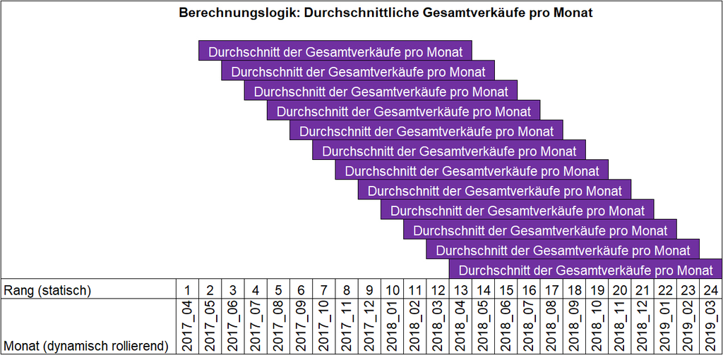

```python
Image("Grafik_Monatliche_Abgänge.jpg")
```

Anschließend der Befehl zur Berechnung der durchschnittlichen historischen Abgänge.

Hierbei sei direkt erwähnt, dass die leten drei Zeilen der nun folgenden Codezellen eine weitere Anweisung beinhalten: Die Zeilen spielen die berechneten Werte je Artikel, direkt zurück an den ensprechenden Rang im Source-Dataframe. Dies geschieht indem eine neue Spalte namens "AvgDisposalsPerMonth" erstellt und benutzt wird:

**Monat 13:**

```python
Variable1 = int(2)
Variable2 = int(13)
Variable2str = str(Variable2)
AvgDisposals_Variable2str = "AvgDisposals"+str(Variable2)

AvgDisposals13 = Source[(Variable1 <= Source.RANG) & (Source.RANG <= Variable2)]
AvgDisposals13 = AvgDisposals13[["ARTICLE", "DisposalsTotal"]]
AvgDisposals13 = AvgDisposals13.groupby('ARTICLE', axis=0, as_index=False).mean()

AvgDisposals13 = AvgDisposals13.rename(columns={'DisposalsTotal': 'AvgDisposalsPerMonth'})
AvgDisposals13["Custom_ID"] = Variable2str +"_"+ AvgDisposals13.ARTICLE.map(str)
AvgDisposals13 = AvgDisposals13[["Custom_ID"] +AvgDisposals13.columns[:-1].tolist()]
AvgDisposals13

Source = pd.merge(Source, AvgDisposals13[["Custom_ID","AvgDisposalsPerMonth"]], on="Custom_ID", how = "left")
Source["AvgDisposalsPerMonth"].fillna(0, inplace=True)
Source = Source.rename(columns={'AvgDisposalsPerMonth': AvgDisposals_Variable2str})
```

**Monat 14:**

```python
Variable1 = int(3)
Variable2 = int(14)
Variable2str = str(Variable2)
AvgDisposals_Variable2str = "AvgDisposals"+str(Variable2)

AvgDisposals14 = Source[(Variable1 <= Source.RANG) & (Source.RANG <= Variable2)]
AvgDisposals14 = AvgDisposals14[["ARTICLE", "DisposalsTotal"]]
AvgDisposals14 = AvgDisposals14.groupby('ARTICLE', axis=0, as_index=False).mean()

AvgDisposals14 = AvgDisposals14.rename(columns={'DisposalsTotal': 'AvgDisposalsPerMonth'})
AvgDisposals14["Custom_ID"] = Variable2str +"_"+ AvgDisposals14.ARTICLE.map(str)
AvgDisposals14 = AvgDisposals14[["Custom_ID"] +AvgDisposals14.columns[:-1].tolist()]
AvgDisposals14

Source = pd.merge(Source, AvgDisposals14[["Custom_ID","AvgDisposalsPerMonth"]], on="Custom_ID", how = "left")
Source["AvgDisposalsPerMonth"].fillna(0, inplace=True)
Source = Source.rename(columns={'AvgDisposalsPerMonth': AvgDisposals_Variable2str})
```

**Monat 15:**

```python
Variable1 = int(4)
Variable2 = int(15)
Variable2str = str(Variable2)
AvgDisposals_Variable2str = "AvgDisposals"+str(Variable2)

AvgDisposals15 = Source[(Variable1 <= Source.RANG) & (Source.RANG <= Variable2)]
AvgDisposals15 = AvgDisposals15[["ARTICLE", "DisposalsTotal"]]
AvgDisposals15 = AvgDisposals15.groupby('ARTICLE', axis=0, as_index=False).mean()

AvgDisposals15 = AvgDisposals15.rename(columns={'DisposalsTotal': 'AvgDisposalsPerMonth'})
AvgDisposals15["Custom_ID"] = Variable2str +"_"+ AvgDisposals15.ARTICLE.map(str)
AvgDisposals15 = AvgDisposals15[["Custom_ID"] +AvgDisposals15.columns[:-1].tolist()]
AvgDisposals15

Source = pd.merge(Source, AvgDisposals15[["Custom_ID","AvgDisposalsPerMonth"]], on="Custom_ID", how = "left")
Source["AvgDisposalsPerMonth"].fillna(0, inplace=True)
Source = Source.rename(columns={'AvgDisposalsPerMonth': AvgDisposals_Variable2str})
```

**Monat 16:**

```python
Variable1 = int(5)
Variable2 = int(16)
Variable2str = str(Variable2)
AvgDisposals_Variable2str = "AvgDisposals"+str(Variable2)

AvgDisposals16 = Source[(Variable1 <= Source.RANG) & (Source.RANG <= Variable2)]
AvgDisposals16 = AvgDisposals16[["ARTICLE", "DisposalsTotal"]]
AvgDisposals16 = AvgDisposals16.groupby('ARTICLE', axis=0, as_index=False).mean()

AvgDisposals16 = AvgDisposals16.rename(columns={'DisposalsTotal': 'AvgDisposalsPerMonth'})
AvgDisposals16["Custom_ID"] = Variable2str +"_"+ AvgDisposals16.ARTICLE.map(str)
AvgDisposals16 = AvgDisposals16[["Custom_ID"] +AvgDisposals16.columns[:-1].tolist()]
AvgDisposals16

Source = pd.merge(Source, AvgDisposals16[["Custom_ID","AvgDisposalsPerMonth"]], on="Custom_ID", how = "left")
Source["AvgDisposalsPerMonth"].fillna(0, inplace=True)
Source = Source.rename(columns={'AvgDisposalsPerMonth': AvgDisposals_Variable2str})
```

**Monat 17:**

```python
Variable1 = int(6)
Variable2 = int(17)
Variable2str = str(Variable2)
AvgDisposals_Variable2str = "AvgDisposals"+str(Variable2)

AvgDisposals17 = Source[(Variable1 <= Source.RANG) & (Source.RANG <= Variable2)]
AvgDisposals17 = AvgDisposals17[["ARTICLE", "DisposalsTotal"]]
AvgDisposals17 = AvgDisposals17.groupby('ARTICLE', axis=0, as_index=False).mean()

AvgDisposals17 = AvgDisposals17.rename(columns={'DisposalsTotal': 'AvgDisposalsPerMonth'})
AvgDisposals17["Custom_ID"] = Variable2str +"_"+ AvgDisposals17.ARTICLE.map(str)
AvgDisposals17 = AvgDisposals17[["Custom_ID"] +AvgDisposals17.columns[:-1].tolist()]
AvgDisposals17

Source = pd.merge(Source, AvgDisposals17[["Custom_ID","AvgDisposalsPerMonth"]], on="Custom_ID", how = "left")
Source["AvgDisposalsPerMonth"].fillna(0, inplace=True)
Source = Source.rename(columns={'AvgDisposalsPerMonth': AvgDisposals_Variable2str})
```

**Monat 18:**

```python
Variable1 = int(7)
Variable2 = int(18)
Variable2str = str(Variable2)
AvgDisposals_Variable2str = "AvgDisposals"+str(Variable2)

AvgDisposals18 = Source[(Variable1 <= Source.RANG) & (Source.RANG <= Variable2)]
AvgDisposals18 = AvgDisposals18[["ARTICLE", "DisposalsTotal"]]
AvgDisposals18 = AvgDisposals18.groupby('ARTICLE', axis=0, as_index=False).mean()

AvgDisposals18 = AvgDisposals18.rename(columns={'DisposalsTotal': 'AvgDisposalsPerMonth'})
AvgDisposals18["Custom_ID"] = Variable2str +"_"+ AvgDisposals18.ARTICLE.map(str)
AvgDisposals18 = AvgDisposals18[["Custom_ID"] +AvgDisposals18.columns[:-1].tolist()]
AvgDisposals18

Source = pd.merge(Source, AvgDisposals18[["Custom_ID","AvgDisposalsPerMonth"]], on="Custom_ID", how = "left")
Source["AvgDisposalsPerMonth"].fillna(0, inplace=True)
Source = Source.rename(columns={'AvgDisposalsPerMonth': AvgDisposals_Variable2str})
```

**Monat 19:**

```python
Variable1 = int(8)
Variable2 = int(19)
Variable2str = str(Variable2)
AvgDisposals_Variable2str = "AvgDisposals"+str(Variable2)

AvgDisposals19 = Source[(Variable1 <= Source.RANG) & (Source.RANG <= Variable2)]
AvgDisposals19 = AvgDisposals19[["ARTICLE", "DisposalsTotal"]]
AvgDisposals19 = AvgDisposals19.groupby('ARTICLE', axis=0, as_index=False).mean()

AvgDisposals19 = AvgDisposals19.rename(columns={'DisposalsTotal': 'AvgDisposalsPerMonth'})
AvgDisposals19["Custom_ID"] = Variable2str +"_"+ AvgDisposals19.ARTICLE.map(str)
AvgDisposals19 = AvgDisposals19[["Custom_ID"] +AvgDisposals19.columns[:-1].tolist()]
AvgDisposals19

Source = pd.merge(Source, AvgDisposals19[["Custom_ID","AvgDisposalsPerMonth"]], on="Custom_ID", how = "left")
Source["AvgDisposalsPerMonth"].fillna(0, inplace=True)
Source = Source.rename(columns={'AvgDisposalsPerMonth': AvgDisposals_Variable2str})
```

**Monat 20:**

```python
Variable1 = int(9)
Variable2 = int(20)
Variable2str = str(Variable2)
AvgDisposals_Variable2str = "AvgDisposals"+str(Variable2)

AvgDisposals20 = Source[(Variable1 <= Source.RANG) & (Source.RANG <= Variable2)]
AvgDisposals20 = AvgDisposals20[["ARTICLE", "DisposalsTotal"]]
AvgDisposals20 = AvgDisposals20.groupby('ARTICLE', axis=0, as_index=False).mean()

AvgDisposals20 = AvgDisposals20.rename(columns={'DisposalsTotal': 'AvgDisposalsPerMonth'})
AvgDisposals20["Custom_ID"] = Variable2str +"_"+ AvgDisposals20.ARTICLE.map(str)
AvgDisposals20 = AvgDisposals20[["Custom_ID"] +AvgDisposals20.columns[:-1].tolist()]
AvgDisposals20

Source = pd.merge(Source, AvgDisposals20[["Custom_ID","AvgDisposalsPerMonth"]], on="Custom_ID", how = "left")
Source["AvgDisposalsPerMonth"].fillna(0, inplace=True)
Source = Source.rename(columns={'AvgDisposalsPerMonth': AvgDisposals_Variable2str})
```

**Monat 21:**

```python
Variable1 = int(10)
Variable2 = int(21)
Variable2str = str(Variable2)
AvgDisposals_Variable2str = "AvgDisposals"+str(Variable2)

AvgDisposals21 = Source[(Variable1 <= Source.RANG) & (Source.RANG <= Variable2)]
AvgDisposals21 = AvgDisposals21[["ARTICLE", "DisposalsTotal"]]
AvgDisposals21 = AvgDisposals21.groupby('ARTICLE', axis=0, as_index=False).mean()

AvgDisposals21 = AvgDisposals21.rename(columns={'DisposalsTotal': 'AvgDisposalsPerMonth'})
AvgDisposals21["Custom_ID"] = Variable2str +"_"+ AvgDisposals21.ARTICLE.map(str)
AvgDisposals21 = AvgDisposals21[["Custom_ID"] +AvgDisposals21.columns[:-1].tolist()]
AvgDisposals21

Source = pd.merge(Source, AvgDisposals21[["Custom_ID","AvgDisposalsPerMonth"]], on="Custom_ID", how = "left")
Source["AvgDisposalsPerMonth"].fillna(0, inplace=True)
Source = Source.rename(columns={'AvgDisposalsPerMonth': AvgDisposals_Variable2str})
```

**Monat 22:**

```python
Variable1 = int(11)
Variable2 = int(22)
Variable2str = str(Variable2)
AvgDisposals_Variable2str = "AvgDisposals"+str(Variable2)

AvgDisposals22 = Source[(Variable1 <= Source.RANG) & (Source.RANG <= Variable2)]
AvgDisposals22 = AvgDisposals22[["ARTICLE", "DisposalsTotal"]]
AvgDisposals22 = AvgDisposals22.groupby('ARTICLE', axis=0, as_index=False).mean()

AvgDisposals22 = AvgDisposals22.rename(columns={'DisposalsTotal': 'AvgDisposalsPerMonth'})
AvgDisposals22["Custom_ID"] = Variable2str +"_"+ AvgDisposals22.ARTICLE.map(str)
AvgDisposals22 = AvgDisposals22[["Custom_ID"] +AvgDisposals22.columns[:-1].tolist()]
AvgDisposals22

Source = pd.merge(Source, AvgDisposals22[["Custom_ID","AvgDisposalsPerMonth"]], on="Custom_ID", how = "left")
Source["AvgDisposalsPerMonth"].fillna(0, inplace=True)
Source = Source.rename(columns={'AvgDisposalsPerMonth': AvgDisposals_Variable2str})
```

**Monat 23:**

```python
Variable1 = int(12)
Variable2 = int(23)
Variable2str = str(Variable2)
AvgDisposals_Variable2str = "AvgDisposals"+str(Variable2)

AvgDisposals23 = Source[(Variable1 <= Source.RANG) & (Source.RANG <= Variable2)]
AvgDisposals23 = AvgDisposals23[["ARTICLE", "DisposalsTotal"]]
AvgDisposals23 = AvgDisposals23.groupby('ARTICLE', axis=0, as_index=False).mean()

AvgDisposals23 = AvgDisposals23.rename(columns={'DisposalsTotal': 'AvgDisposalsPerMonth'})
AvgDisposals23["Custom_ID"] = Variable2str +"_"+ AvgDisposals23.ARTICLE.map(str)
AvgDisposals23 = AvgDisposals23[["Custom_ID"] +AvgDisposals23.columns[:-1].tolist()]
AvgDisposals23

Source = pd.merge(Source, AvgDisposals23[["Custom_ID","AvgDisposalsPerMonth"]], on="Custom_ID", how = "left")
Source["AvgDisposalsPerMonth"].fillna(0, inplace=True)
Source = Source.rename(columns={'AvgDisposalsPerMonth': AvgDisposals_Variable2str})
```

**Monat 24:**

```python
Variable1 = int(13)
Variable2 = int(24)
Variable2str = str(Variable2)
AvgDisposals_Variable2str = "AvgDisposals"+str(Variable2)

AvgDisposals24 = Source[(Variable1 <= Source.RANG) & (Source.RANG <= Variable2)]
AvgDisposals24 = AvgDisposals24[["ARTICLE", "DisposalsTotal"]]
AvgDisposals24 = AvgDisposals24.groupby('ARTICLE', axis=0, as_index=False).mean()

AvgDisposals24 = AvgDisposals24.rename(columns={'DisposalsTotal': 'AvgDisposalsPerMonth'})
AvgDisposals24["Custom_ID"] = Variable2str +"_"+ AvgDisposals24.ARTICLE.map(str)
AvgDisposals24 = AvgDisposals24[["Custom_ID"] +AvgDisposals24.columns[:-1].tolist()]
AvgDisposals24

Source = pd.merge(Source, AvgDisposals24[["Custom_ID","AvgDisposalsPerMonth"]], on="Custom_ID", how = "left")
Source["AvgDisposalsPerMonth"].fillna(0, inplace=True)
Source = Source.rename(columns={'AvgDisposalsPerMonth': AvgDisposals_Variable2str})
```

Nachdem im obigen Code zwölf neue Spalten mit Einzelwerten je Rang (Rang 13-24) an den Dataframe angehängt wurden, können diese Werte in einer neuen Spalte "AvgDisposalsPerMonthPCS" zusammengefasst werden.

Anschließend erfolgt ein Runden auf Ganzzahlen sowie eine Datentypumwandlung der Spalte "AvgDisposalsPerMonthPCS" von einem Float zu einem Integer. Fehlende Werte in den Rangnummern 1-12 sind nicht relevant und werden mit "not relevant" belabelt.

Zuletzt können die zwölf Zwischenrechnungsspalten gelöscht werden. Sie werden von nun an nicht mehr benötigt und weißen nur noch redundante Daten auf.

Folgender Befehl führt oben beschriebenes Vorgehen aus:

```python
Source["AvgDisposalsPerMonthPCS"] = Source[["AvgDisposals13","AvgDisposals14","AvgDisposals15","AvgDisposals16","AvgDisposals17","AvgDisposals18","AvgDisposals19","AvgDisposals20","AvgDisposals21","AvgDisposals22","AvgDisposals23","AvgDisposals24"]].min(axis=1)*(-1)
Source["AvgDisposalsPerMonthPCS"] = Source["AvgDisposalsPerMonthPCS"].round(0).astype(int)

Source["AvgDisposalsPerMonthPCS"].fillna("not relevant", inplace=True)
Source = Source.drop(columns=["AvgDisposals13","AvgDisposals14","AvgDisposals15","AvgDisposals16","AvgDisposals17","AvgDisposals18","AvgDisposals19","AvgDisposals20","AvgDisposals21","AvgDisposals22","AvgDisposals23","AvgDisposals24"])
```

Um die durchschnittlichen Abgänge pro Monat in Euro-Beträgen auszudrücken wird schließlich eine weitere Spalte "AvgDisposalsPerMonthLP1" im Dataframe angelegt, welche sich aus der Multiplikation der oben generierten Spalte mit dem LP1 je Artikel berechnet:

```python
Source["AvgDisposalsPerMonthLP1"] = Source["AvgDisposalsPerMonthPCS"]*Source["LP1_PER_ARTICLE_EUR"]
```

## 3.3 Berechnung der Optimum QTY

Im folgenden Abschnitt wird die zu lagernde Sollmenge die sog. "Optimalmenge" berechnet. Sie basiert auf dem oben berechneten Monatsbedarf je Artikel.

Weiter soll die Optimalmenge die Wiederbeschaffungszeiten berücksichtigen. Je höher die Produktions- und Transport-Wiederbeschaffungszeiten, desto höher soll nach dem logistischen Modell die Optimalmenge für die Tochtergesellschaften ausfallen.

Für die Berücksichtigung der Wiederbeschaffungszeiten werden die zu Beginn eingelesenen Stammdatentabellen

- "Production-Lead-Time" (Prduktionsdauer je Produktgruppe) und
- "Transportation-Lead-Time" (Transportdauer von Weißenhorn bis zum Empfänger)

benötigt.

Da beide Stammdatentabellen in Wochen angegeben werden, muss der Monatsbedarf je Artikel durch vier dividiert werden.

Folgende Grafik veranschaulicht die Berechnung des Wochenbedarfes:

[figure not shown]

Anschließend die grafische Darstellung, wie die Optimalmenge je Artikel berechnet wird. Auf die Ergebnisbewertung (Vergleich mit QTY on Stock) wird im Anschluss der Optimum-Quantity Berechnung eingegangen.

[figure not shown]

Zunächst also die Codes zur Berechnung der Optimalmenge:

Zur Wiederholung sei nochmals erwähnt, dass der Code

- die Produktionsdauer je Produktgruppe
- die Transport-Lieferzeiten je Land
- die durchschnittlichen Abgänge je Artikel

berücksichtigt.

Sollte die Produktgruppe eines Artikels nicht in der "Production-Lead-Time" Tabelle hinterlegt sein, wurde entschieden, einen Defaultwert von 6 Wochen für die Produktionsdauer in den Code zu implementieren.

Auch hier werden die Werte nach deren Berechnung direkt zurück in den Dataframe (unter einer neuen Spalte) gespielt:

**Monat 13:**

```python
Variable1 = int(2)
Variable2 = int(13)
Variable2str = str(Variable2)
OptQTY_Variable2str = "OptQTY"+str(Variable2)

DF13 = Source[(Variable1 <= Source.RANG) & (Source.RANG <= Variable2)]
DF13 = DF13[["ARTICLE", "DisposalsTotal"]]
DF13 = DF13.groupby('ARTICLE', axis=0, as_index=False).mean()
DF13 = DF13.rename(columns={'DisposalsTotal': 'DisposalsPerWeek'})
DF13["Custom_ID"] = Variable2str +"_"+ DF13.ARTICLE.map(str)
DF13 = DF13[["Custom_ID"] + DF13.columns[:-1].tolist()]

if not 'PG' in DF13.columns:
    DF13 = DF13.join(Source[["PG"]], on="ARTICLE", how = "left")
if not 'ProductionLeadTimeWeeks' in DF13.columns:
    DF13 = DF13.join(ProductionLeadTime[["ProductionLeadTimeWeeks"]], on="PG", how = "left")
    DF13["ProductionLeadTimeWeeks"].fillna(6, inplace=True)

KeyCountry = Source.loc[0, "PSD_FA"]
LeadTimeIndex = TransportationLeadTime[TransportationLeadTime["Land_ID_Text (1 Digit)"] == KeyCountry].index
LeadTime = TransportationLeadTime["Transport Lead Time"].loc[LeadTimeIndex].values.astype("d")[0]
DF13Rows = len(DF13)
LeadTimeArray = [LeadTime] * DF13Rows
DF13["TransportationLeadTimeWeeks"] = LeadTimeArray

DF13["TotalLeadTime"] = DF13["ProductionLeadTimeWeeks"] + DF13["TransportationLeadTimeWeeks"]

DF13["OptimumQTY"] = DF13["DisposalsPerWeek"]*DF13["TotalLeadTime"]*(-1)

Source = pd.merge(Source, DF13[["Custom_ID","OptimumQTY"]], on="Custom_ID", how = "left")
Source["OptimumQTY"].fillna(0, inplace=True)
Source = Source.rename(columns={'OptimumQTY': OptQTY_Variable2str})
```

**Monat 14:**

```python
Variable1 = int(3)
Variable2 = int(14)
Variable2str = str(Variable2)
OptQTY_Variable2str = "OptQTY"+str(Variable2)

DF14 = Source[(Variable1 <= Source.RANG) & (Source.RANG <= Variable2)]
DF14 = DF14[["ARTICLE", "DisposalsTotal"]]
DF14 = DF14.groupby('ARTICLE', axis=0, as_index=False).mean()
DF14 = DF14.rename(columns={'DisposalsTotal': 'DisposalsPerWeek'})
DF14["Custom_ID"] = Variable2str +"_"+ DF14.ARTICLE.map(str)
DF14 = DF14[["Custom_ID"] + DF14.columns[:-1].tolist()]

if not 'PG' in DF14.columns:
    DF14 = DF14.join(Source[["PG"]], on="ARTICLE", how = "left")
if not 'ProductionLeadTimeWeeks' in DF14.columns:
    DF14 = DF14.join(ProductionLeadTime[["ProductionLeadTimeWeeks"]], on="PG", how = "left")
    DF14["ProductionLeadTimeWeeks"].fillna(6, inplace=True)

KeyCountry = Source.loc[0, "PSD_FA"]
LeadTimeIndex = TransportationLeadTime[TransportationLeadTime["Land_ID_Text (1 Digit)"] == KeyCountry].index
LeadTime = TransportationLeadTime["Transport Lead Time"].loc[LeadTimeIndex].values.astype("d")[0]
DF14Rows = len(DF14)
LeadTimeArray = [LeadTime] * DF14Rows
DF14["TransportationLeadTimeWeeks"] = LeadTimeArray

DF14["TotalLeadTime"] = DF14["ProductionLeadTimeWeeks"] + DF14["TransportationLeadTimeWeeks"]

DF14["OptimumQTY"] = DF14["DisposalsPerWeek"]*DF14["TotalLeadTime"]*(-1)

Source = pd.merge(Source, DF14[["Custom_ID","OptimumQTY"]], on="Custom_ID", how = "left")
Source["OptimumQTY"].fillna(0, inplace=True)
Source = Source.rename(columns={'OptimumQTY': OptQTY_Variable2str})
```

**Monat 15:**

```python
Variable1 = int(4)
Variable2 = int(15)
Variable2str = str(Variable2)
OptQTY_Variable2str = "OptQTY"+str(Variable2)

DF15 = Source[(Variable1 <= Source.RANG) & (Source.RANG <= Variable2)]
DF15 = DF15[["ARTICLE", "DisposalsTotal"]]
DF15 = DF15.groupby('ARTICLE', axis=0, as_index=False).mean()
DF15 = DF15.rename(columns={'DisposalsTotal': 'DisposalsPerWeek'})
DF15["Custom_ID"] = Variable2str +"_"+ DF15.ARTICLE.map(str)
DF15 = DF15[["Custom_ID"] + DF15.columns[:-1].tolist()]

if not 'PG' in DF15.columns:
    DF15 = DF15.join(Source[["PG"]], on="ARTICLE", how = "left")
if not 'ProductionLeadTimeWeeks' in DF15.columns:
    DF15 = DF15.join(ProductionLeadTime[["ProductionLeadTimeWeeks"]], on="PG", how = "left")
    DF15["ProductionLeadTimeWeeks"].fillna(6, inplace=True)

KeyCountry = Source.loc[0, "PSD_FA"]
LeadTimeIndex = TransportationLeadTime[TransportationLeadTime["Land_ID_Text (1 Digit)"] == KeyCountry].index
LeadTime = TransportationLeadTime["Transport Lead Time"].loc[LeadTimeIndex].values.astype("d")[0]
DF15Rows = len(DF15)
LeadTimeArray = [LeadTime] * DF15Rows
DF15["TransportationLeadTimeWeeks"] = LeadTimeArray

DF15["TotalLeadTime"] = DF15["ProductionLeadTimeWeeks"] + DF15["TransportationLeadTimeWeeks"]

DF15["OptimumQTY"] = DF15["DisposalsPerWeek"]*DF15["TotalLeadTime"]*(-1)

Source = pd.merge(Source, DF15[["Custom_ID","OptimumQTY"]], on="Custom_ID", how = "left")
Source["OptimumQTY"].fillna(0, inplace=True)
Source = Source.rename(columns={'OptimumQTY': OptQTY_Variable2str})
```

**Monat 16:**

```python
Variable1 = int(5)
Variable2 = int(16)
Variable2str = str(Variable2)
OptQTY_Variable2str = "OptQTY"+str(Variable2)

DF16 = Source[(Variable1 <= Source.RANG) & (Source.RANG <= Variable2)]
DF16 = DF16[["ARTICLE", "DisposalsTotal"]]
DF16 = DF16.groupby('ARTICLE', axis=0, as_index=False).mean()
DF16 = DF16.rename(columns={'DisposalsTotal': 'DisposalsPerWeek'})
DF16["Custom_ID"] = Variable2str +"_"+ DF16.ARTICLE.map(str)
DF16 = DF16[["Custom_ID"] + DF16.columns[:-1].tolist()]

if not 'PG' in DF16.columns:
    DF16 = DF16.join(Source[["PG"]], on="ARTICLE", how = "left")
if not 'ProductionLeadTimeWeeks' in DF16.columns:
    DF16 = DF16.join(ProductionLeadTime[["ProductionLeadTimeWeeks"]], on="PG", how = "left")
    DF16["ProductionLeadTimeWeeks"].fillna(6, inplace=True)

KeyCountry = Source.loc[0, "PSD_FA"]
LeadTimeIndex = TransportationLeadTime[TransportationLeadTime["Land_ID_Text (1 Digit)"] == KeyCountry].index
LeadTime = TransportationLeadTime["Transport Lead Time"].loc[LeadTimeIndex].values.astype("d")[0]
DF16Rows = len(DF16)
LeadTimeArray = [LeadTime] * DF16Rows
DF16["TransportationLeadTimeWeeks"] = LeadTimeArray

DF16["TotalLeadTime"] = DF16["ProductionLeadTimeWeeks"] + DF16["TransportationLeadTimeWeeks"]

DF16["OptimumQTY"] = DF16["DisposalsPerWeek"]*DF16["TotalLeadTime"]*(-1)

Source = pd.merge(Source, DF16[["Custom_ID","OptimumQTY"]], on="Custom_ID", how = "left")
Source["OptimumQTY"].fillna(0, inplace=True)
Source = Source.rename(columns={'OptimumQTY': OptQTY_Variable2str})
```

**Monat 17:**

```python
Variable1 = int(6)
Variable2 = int(17)
Variable2str = str(Variable2)
OptQTY_Variable2str = "OptQTY"+str(Variable2)

DF17 = Source[(Variable1 <= Source.RANG) & (Source.RANG <= Variable2)]
DF17 = DF17[["ARTICLE", "DisposalsTotal"]]
DF17 = DF17.groupby('ARTICLE', axis=0, as_index=False).mean()
DF17 = DF17.rename(columns={'DisposalsTotal': 'DisposalsPerWeek'})
DF17["Custom_ID"] = Variable2str +"_"+ DF17.ARTICLE.map(str)
DF17 = DF17[["Custom_ID"] + DF17.columns[:-1].tolist()]

if not 'PG' in DF17.columns:
    DF17 = DF17.join(Source[["PG"]], on="ARTICLE", how = "left")
if not 'ProductionLeadTimeWeeks' in DF17.columns:
    DF17 = DF17.join(ProductionLeadTime[["ProductionLeadTimeWeeks"]], on="PG", how = "left")
    DF17["ProductionLeadTimeWeeks"].fillna(6, inplace=True)

KeyCountry = Source.loc[0, "PSD_FA"]
LeadTimeIndex = TransportationLeadTime[TransportationLeadTime["Land_ID_Text (1 Digit)"] == KeyCountry].index
LeadTime = TransportationLeadTime["Transport Lead Time"].loc[LeadTimeIndex].values.astype("d")[0]
DF17Rows = len(DF17)
LeadTimeArray = [LeadTime] * DF17Rows
DF17["TransportationLeadTimeWeeks"] = LeadTimeArray

DF17["TotalLeadTime"] = DF17["ProductionLeadTimeWeeks"] + DF17["TransportationLeadTimeWeeks"]

DF17["OptimumQTY"] = DF17["DisposalsPerWeek"]*DF17["TotalLeadTime"]*(-1)

Source = pd.merge(Source, DF17[["Custom_ID","OptimumQTY"]], on="Custom_ID", how = "left")
Source["OptimumQTY"].fillna(0, inplace=True)
Source = Source.rename(columns={'OptimumQTY': OptQTY_Variable2str})
```

**Monat 18:**

```python
Variable1 = int(7)
Variable2 = int(18)
Variable2str = str(Variable2)
OptQTY_Variable2str = "OptQTY"+str(Variable2)

DF18 = Source[(Variable1 <= Source.RANG) & (Source.RANG <= Variable2)]
DF18 = DF18[["ARTICLE", "DisposalsTotal"]]
DF18 = DF18.groupby('ARTICLE', axis=0, as_index=False).mean()
DF18 = DF18.rename(columns={'DisposalsTotal': 'DisposalsPerWeek'})
DF18["Custom_ID"] = Variable2str +"_"+ DF18.ARTICLE.map(str)
DF18 = DF18[["Custom_ID"] + DF18.columns[:-1].tolist()]

if not 'PG' in DF18.columns:
    DF18 = DF18.join(Source[["PG"]], on="ARTICLE", how = "left")
if not 'ProductionLeadTimeWeeks' in DF18.columns:
    DF18 = DF18.join(ProductionLeadTime[["ProductionLeadTimeWeeks"]], on="PG", how = "left")
    DF18["ProductionLeadTimeWeeks"].fillna(6, inplace=True)

KeyCountry = Source.loc[0, "PSD_FA"]
LeadTimeIndex = TransportationLeadTime[TransportationLeadTime["Land_ID_Text (1 Digit)"] == KeyCountry].index
LeadTime = TransportationLeadTime["Transport Lead Time"].loc[LeadTimeIndex].values.astype("d")[0]
DF18Rows = len(DF18)
LeadTimeArray = [LeadTime] * DF18Rows
DF18["TransportationLeadTimeWeeks"] = LeadTimeArray

DF18["TotalLeadTime"] = DF18["ProductionLeadTimeWeeks"] + DF18["TransportationLeadTimeWeeks"]

DF18["OptimumQTY"] = DF18["DisposalsPerWeek"]*DF18["TotalLeadTime"]*(-1)

Source = pd.merge(Source, DF18[["Custom_ID","OptimumQTY"]], on="Custom_ID", how = "left")
Source["OptimumQTY"].fillna(0, inplace=True)
Source = Source.rename(columns={'OptimumQTY': OptQTY_Variable2str})
```

**Monat 19:**

```python
Variable1 = int(8)
Variable2 = int(19)
Variable2str = str(Variable2)
OptQTY_Variable2str = "OptQTY"+str(Variable2)

DF19 = Source[(Variable1 <= Source.RANG) & (Source.RANG <= Variable2)]
DF19 = DF19[["ARTICLE", "DisposalsTotal"]]
DF19 = DF19.groupby('ARTICLE', axis=0, as_index=False).mean()
DF19 = DF19.rename(columns={'DisposalsTotal': 'DisposalsPerWeek'})
DF19["Custom_ID"] = Variable2str +"_"+ DF19.ARTICLE.map(str)
DF19 = DF19[["Custom_ID"] + DF19.columns[:-1].tolist()]

if not 'PG' in DF19.columns:
    DF19 = DF19.join(Source[["PG"]], on="ARTICLE", how = "left")
if not 'ProductionLeadTimeWeeks' in DF19.columns:
    DF19 = DF19.join(ProductionLeadTime[["ProductionLeadTimeWeeks"]], on="PG", how = "left")
    DF19["ProductionLeadTimeWeeks"].fillna(6, inplace=True)

KeyCountry = Source.loc[0, "PSD_FA"]
LeadTimeIndex = TransportationLeadTime[TransportationLeadTime["Land_ID_Text (1 Digit)"] == KeyCountry].index
LeadTime = TransportationLeadTime["Transport Lead Time"].loc[LeadTimeIndex].values.astype("d")[0]
DF19Rows = len(DF19)
LeadTimeArray = [LeadTime] * DF19Rows
DF19["TransportationLeadTimeWeeks"] = LeadTimeArray

DF19["TotalLeadTime"] = DF19["ProductionLeadTimeWeeks"] + DF19["TransportationLeadTimeWeeks"]

DF19["OptimumQTY"] = DF19["DisposalsPerWeek"]*DF19["TotalLeadTime"]*(-1)

Source = pd.merge(Source, DF19[["Custom_ID","OptimumQTY"]], on="Custom_ID", how = "left")
Source["OptimumQTY"].fillna(0, inplace=True)
Source = Source.rename(columns={'OptimumQTY': OptQTY_Variable2str})
```

**Monat 20:**

```python
Variable1 = int(9)
Variable2 = int(20)
Variable2str = str(Variable2)
OptQTY_Variable2str = "OptQTY"+str(Variable2)

DF20 = Source[(Variable1 <= Source.RANG) & (Source.RANG <= Variable2)]
DF20 = DF20[["ARTICLE", "DisposalsTotal"]]
DF20 = DF20.groupby('ARTICLE', axis=0, as_index=False).mean()
DF20 = DF20.rename(columns={'DisposalsTotal': 'DisposalsPerWeek'})
DF20["Custom_ID"] = Variable2str +"_"+ DF20.ARTICLE.map(str)
DF20 = DF20[["Custom_ID"] + DF20.columns[:-1].tolist()]

if not 'PG' in DF20.columns:
    DF20 = DF20.join(Source[["PG"]], on="ARTICLE", how = "left")
if not 'ProductionLeadTimeWeeks' in DF20.columns:
    DF20 = DF20.join(ProductionLeadTime[["ProductionLeadTimeWeeks"]], on="PG", how = "left")
    DF20["ProductionLeadTimeWeeks"].fillna(6, inplace=True)

KeyCountry = Source.loc[0, "PSD_FA"]
LeadTimeIndex = TransportationLeadTime[TransportationLeadTime["Land_ID_Text (1 Digit)"] == KeyCountry].index
LeadTime = TransportationLeadTime["Transport Lead Time"].loc[LeadTimeIndex].values.astype("d")[0]
DF20Rows = len(DF20)
LeadTimeArray = [LeadTime] * DF20Rows
DF20["TransportationLeadTimeWeeks"] = LeadTimeArray

DF20["TotalLeadTime"] = DF20["ProductionLeadTimeWeeks"] + DF20["TransportationLeadTimeWeeks"]

DF20["OptimumQTY"] = DF20["DisposalsPerWeek"]*DF20["TotalLeadTime"]*(-1)

Source = pd.merge(Source, DF20[["Custom_ID","OptimumQTY"]], on="Custom_ID", how = "left")
Source["OptimumQTY"].fillna(0, inplace=True)
Source = Source.rename(columns={'OptimumQTY': OptQTY_Variable2str})
```

**Monat 21:**

```python
Variable1 = int(10)
Variable2 = int(21)
Variable2str = str(Variable2)
OptQTY_Variable2str = "OptQTY"+str(Variable2)

DF21 = Source[(Variable1 <= Source.RANG) & (Source.RANG <= Variable2)]
DF21 = DF21[["ARTICLE", "DisposalsTotal"]]
DF21 = DF21.groupby('ARTICLE', axis=0, as_index=False).mean()
DF21 = DF21.rename(columns={'DisposalsTotal': 'DisposalsPerWeek'})
DF21["Custom_ID"] = Variable2str +"_"+ DF21.ARTICLE.map(str)
DF21 = DF21[["Custom_ID"] + DF21.columns[:-1].tolist()]

if not 'PG' in DF21.columns:
    DF21 = DF21.join(Source[["PG"]], on="ARTICLE", how = "left")
if not 'ProductionLeadTimeWeeks' in DF21.columns:
    DF21 = DF21.join(ProductionLeadTime[["ProductionLeadTimeWeeks"]], on="PG", how = "left")
    DF21["ProductionLeadTimeWeeks"].fillna(6, inplace=True)

KeyCountry = Source.loc[0, "PSD_FA"]
LeadTimeIndex = TransportationLeadTime[TransportationLeadTime["Land_ID_Text (1 Digit)"] == KeyCountry].index
LeadTime = TransportationLeadTime["Transport Lead Time"].loc[LeadTimeIndex].values.astype("d")[0]
DF21Rows = len(DF21)
LeadTimeArray = [LeadTime] * DF21Rows
DF21["TransportationLeadTimeWeeks"] = LeadTimeArray

DF21["TotalLeadTime"] = DF21["ProductionLeadTimeWeeks"] + DF21["TransportationLeadTimeWeeks"]

DF21["OptimumQTY"] = DF21["DisposalsPerWeek"]*DF21["TotalLeadTime"]*(-1)

Source = pd.merge(Source, DF21[["Custom_ID","OptimumQTY"]], on="Custom_ID", how = "left")
Source["OptimumQTY"].fillna(0, inplace=True)
Source = Source.rename(columns={'OptimumQTY': OptQTY_Variable2str})
```

**Monat 22:**

```python
Variable1 = int(11)
Variable2 = int(22)
Variable2str = str(Variable2)
OptQTY_Variable2str = "OptQTY"+str(Variable2)

DF22 = Source[(Variable1 <= Source.RANG) & (Source.RANG <= Variable2)]
DF22 = DF22[["ARTICLE", "DisposalsTotal"]]
DF22 = DF22.groupby('ARTICLE', axis=0, as_index=False).mean()
DF22 = DF22.rename(columns={'DisposalsTotal': 'DisposalsPerWeek'})
DF22["Custom_ID"] = Variable2str +"_"+ DF22.ARTICLE.map(str)
DF22 = DF22[["Custom_ID"] + DF22.columns[:-1].tolist()]

if not 'PG' in DF22.columns:
    DF22 = DF22.join(Source[["PG"]], on="ARTICLE", how = "left")
if not 'ProductionLeadTimeWeeks' in DF22.columns:
    DF22 = DF22.join(ProductionLeadTime[["ProductionLeadTimeWeeks"]], on="PG", how = "left")
    DF22["ProductionLeadTimeWeeks"].fillna(6, inplace=True)

KeyCountry = Source.loc[0, "PSD_FA"]
LeadTimeIndex = TransportationLeadTime[TransportationLeadTime["Land_ID_Text (1 Digit)"] == KeyCountry].index
LeadTime = TransportationLeadTime["Transport Lead Time"].loc[LeadTimeIndex].values.astype("d")[0]
DF22Rows = len(DF22)
LeadTimeArray = [LeadTime] * DF22Rows
DF22["TransportationLeadTimeWeeks"] = LeadTimeArray

DF22["TotalLeadTime"] = DF22["ProductionLeadTimeWeeks"] + DF22["TransportationLeadTimeWeeks"]

DF22["OptimumQTY"] = DF22["DisposalsPerWeek"]*DF22["TotalLeadTime"]*(-1)

Source = pd.merge(Source, DF22[["Custom_ID","OptimumQTY"]], on="Custom_ID", how = "left")
Source["OptimumQTY"].fillna(0, inplace=True)
Source = Source.rename(columns={'OptimumQTY': OptQTY_Variable2str})
```

**Monat 23:**

```python
Variable1 = int(12)
Variable2 = int(23)
Variable2str = str(Variable2)
OptQTY_Variable2str = "OptQTY"+str(Variable2)

DF23 = Source[(Variable1 <= Source.RANG) & (Source.RANG <= Variable2)]
DF23 = DF23[["ARTICLE", "DisposalsTotal"]]
DF23 = DF23.groupby('ARTICLE', axis=0, as_index=False).mean()
DF23 = DF23.rename(columns={'DisposalsTotal': 'DisposalsPerWeek'})
DF23["Custom_ID"] = Variable2str +"_"+ DF23.ARTICLE.map(str)
DF23 = DF23[["Custom_ID"] + DF23.columns[:-1].tolist()]

if not 'PG' in DF23.columns:
    DF23 = DF23.join(Source[["PG"]], on="ARTICLE", how = "left")
if not 'ProductionLeadTimeWeeks' in DF23.columns:
    DF23 = DF23.join(ProductionLeadTime[["ProductionLeadTimeWeeks"]], on="PG", how = "left")
    DF23["ProductionLeadTimeWeeks"].fillna(6, inplace=True)

KeyCountry = Source.loc[0, "PSD_FA"]
LeadTimeIndex = TransportationLeadTime[TransportationLeadTime["Land_ID_Text (1 Digit)"] == KeyCountry].index
LeadTime = TransportationLeadTime["Transport Lead Time"].loc[LeadTimeIndex].values.astype("d")[0]
DF23Rows = len(DF23)
LeadTimeArray = [LeadTime] * DF23Rows
DF23["TransportationLeadTimeWeeks"] = LeadTimeArray

DF23["TotalLeadTime"] = DF23["ProductionLeadTimeWeeks"] + DF23["TransportationLeadTimeWeeks"]

DF23["OptimumQTY"] = DF23["DisposalsPerWeek"]*DF23["TotalLeadTime"]*(-1)

Source = pd.merge(Source, DF23[["Custom_ID","OptimumQTY"]], on="Custom_ID", how = "left")
Source["OptimumQTY"].fillna(0, inplace=True)
Source = Source.rename(columns={'OptimumQTY': OptQTY_Variable2str})
```

**Monat 24:**

```python
Variable1 = int(13)
Variable2 = int(24)
Variable2str = str(Variable2)
OptQTY_Variable2str = "OptQTY"+str(Variable2)

DF24 = Source[(Variable1 <= Source.RANG) & (Source.RANG <= Variable2)]
DF24 = DF24[["ARTICLE", "DisposalsTotal"]]
DF24 = DF24.groupby('ARTICLE', axis=0, as_index=False).mean()
DF24 = DF24.rename(columns={'DisposalsTotal': 'DisposalsPerWeek'})
DF24["Custom_ID"] = Variable2str +"_"+ DF24.ARTICLE.map(str)
DF24 = DF24[["Custom_ID"] + DF24.columns[:-1].tolist()]

if not 'PG' in DF24.columns:
    DF24 = DF24.join(Source[["PG"]], on="ARTICLE", how = "left")
if not 'ProductionLeadTimeWeeks' in DF24.columns:
    DF24 = DF24.join(ProductionLeadTime[["ProductionLeadTimeWeeks"]], on="PG", how = "left")
    DF24["ProductionLeadTimeWeeks"].fillna(6, inplace=True)

KeyCountry = Source.loc[0, "PSD_FA"]
LeadTimeIndex = TransportationLeadTime[TransportationLeadTime["Land_ID_Text (1 Digit)"] == KeyCountry].index
LeadTime = TransportationLeadTime["Transport Lead Time"].loc[LeadTimeIndex].values.astype("d")[0]
DF24Rows = len(DF24)
LeadTimeArray = [LeadTime] * DF24Rows
DF24["TransportationLeadTimeWeeks"] = LeadTimeArray

DF24["TotalLeadTime"] = DF24["ProductionLeadTimeWeeks"] + DF24["TransportationLeadTimeWeeks"]

DF24["OptimumQTY"] = DF24["DisposalsPerWeek"]*DF24["TotalLeadTime"]*(-1)

Source = pd.merge(Source, DF24[["Custom_ID","OptimumQTY"]], on="Custom_ID", how = "left")
Source["OptimumQTY"].fillna(0, inplace=True)
Source = Source.rename(columns={'OptimumQTY': OptQTY_Variable2str})
```

Ähnlich der Berechnung der durchschnittlichen Abgänge wird folgender Befehl durchgeführt:

- es wird eine zusammenfassende Spalte der oben berechneten Optimalmengen je Monat erstellt
- diese Werte werden als Integer umgewandelt
- fehlende Werte werden durch "not relevant" ersetzt und
- die nicht mehr benötigten Kalkulationsspalten (OptQTY13 - OptQTY24) werden gelöscht.

Folgender Code führt die Prozedur durch:

```python
Source["OptimumQTYPCS"] = Source[["OptQTY13","OptQTY14","OptQTY15","OptQTY16","OptQTY17","OptQTY18","OptQTY19","OptQTY20","OptQTY21","OptQTY22","OptQTY23","OptQTY24"]].max(axis=1)/4
Source["OptimumQTYPCS"] = Source["OptimumQTYPCS"].round(0).astype(int)
Source["OptimumQTYPCS"].fillna("not relevant", inplace=True)
Source = Source.drop(columns=["OptQTY13","OptQTY14","OptQTY15","OptQTY16","OptQTY17","OptQTY18","OptQTY19","OptQTY20","OptQTY21","OptQTY22","OptQTY23","OptQTY24"])
```

Zusammenfassend ist festzuhalten, dass das Ergebnis dieses Abschnittes eine artikelspezifische berechnete Spalte innerhalb des Dataframes ergibt, welche die zu lagernde Menge, basierend seiner Nachfrage und Wiederbeschaffungszeiten beürcksichtigt.

Mit diesem Ergebniswert kann im nächsten Abschnitt ein Vergleich zwischen As-Is Menge auf Lager und berechneter Optimum-QTY angestellt werden.

## 3.4 Vergleich As-Is Menge auf Lager vs. berechneter Soll Menge

```python
Image(url= "https://img.freepik.com/fotos-kostenlos/nahaufnahme-der-berechnungsrechnungen-der-person-auf-taschenrechner_1262-14857.jpg?size=626&ext=jpg", width = 800)
```

[figure not shown]

In diesem Abschnitt werden also die errechneten Optimalmengen mit den aktuellen Lagerbeständen der PERI Tochter Norwegen verglichen.

Dabei werden dem Dataframe erneut Spalten hinzugefügt:

Zunächst werden die Überkapazitäten bzw. Unterkapazitäten je Artikel in Stück berechnet.

Die Kalkulation erfolgt ausschließlich für Datenzeilen bei denen die Rangzahl >= 13 ist. Dies ist darauf zurückzuführen, dass der OptimumQTY Algorithmus im vorigen Abschnitt nur für diese Ränge Ergebniswerte lieferte.

```python
Source["OvercapacitiesPCS"]  =  np.where((Source["RANG"] >=13) & (Source["OptimumQTYPCS"] < Source["QTYSTOCK_LAST_DAY"]),Source["QTYSTOCK_LAST_DAY"]- Source["OptimumQTYPCS"] , 0)
Source["UndercapacitiesPCS"] = np.where((Source["RANG"] >=13) & (Source["OptimumQTYPCS"] > Source["QTYSTOCK_LAST_DAY"]),Source["OptimumQTYPCS"]- Source["QTYSTOCK_LAST_DAY"] , 0)
```

Anschließend werden die Über- und Unterkapazitäten in Stück mit dem LP1 je Artikel multipliziert.

Dies dient dazu, dass später der Dataframe nach Euro-Werten (Über-/Unterkapazitäten) absteigend sortiert werden kann.

Eine Sortierung des Dataframes nach Stück wäre hierbei nicht sinnhaft, da beispielsweise 10.000 geringwertige Artikel in der Überkapazität weniger kapitalintensiv sein könnten als 5 hochwertige Artikel in der Überkapazität.

Mit Hilfe des Wertansatzes kann dieses Problem umgangen werden:

```python
Source["OvercapacitiesLP1"]  = Source["OvercapacitiesPCS"]*Source["LP1_PER_ARTICLE_EUR"]
Source["UndercapacitiesLP1"] = Source["UndercapacitiesPCS"]*Source["LP1_PER_ARTICLE_EUR"]
```

Im letzten Schritt werden die errechneten Optimalmengen mit dem LP1 Wert je Artikel multipliziert. Dies dient dazu, später eine Aussage treffen zu können, welcher Lagerbestandswert in Summe sich ergeben würde, wenn man den errechneten Optimalmengen blind trauen würde.

Auch diese Kennzahl kann später mit der aktuellen Lagerbestandswerten verglichen werden.

```python
Source["OptimumQTY_LP1"] = Source["OptimumQTYPCS"]*Source["LP1_PER_ARTICLE_EUR"]
```

## 3.5 Lagerbestandsreichweite

```python
Image(url= "https://www.xpertio.net/uploads/profile/peri-gmbh-viersen_63592599792113.jpg", width = 800)
```

[figure not shown]

Eine im Logistikcontrolling zentrale Kennzahl ist die **Lagerbestandsreichweite.**

Sie wird berechnet indem bestimmte Bestände durch historische Abgangswerte dividiert werden.

Das Ergebnis liefert eine Kennzahl die besagt, wieviele Perioden (je nach Kalkulationsbasis z.B. Monate) das Unternehmen bei gleich bleibender Kundennachfrage ohne Wiederbefüllung der aktuellen Bestände lieferfähig wäre.

Zur Übersicht, welche Bestands- und Abgangsspalten für die Artikelkalkulationen benötigt werden, werden zunächst nochmals die ersten 5 Zeilen des Source-Dataframe in seiner aktuellen Form dargestellt:

```python
Source.head()
```

|  | Custom_ID | Country | PSD_FA | STOCKYARD | CALMONTH | RANG | ARTICLE | ARTICLE_TXT | PG | PG_TXT | REVENUE_FLAG | BASE_UOM | PRICE_UNIT | HPC_PER_ARTICLE_EUR | NBV_PER_ARTICLE_EUR | LPT_PER_ARTICLE_EUR | LP1_PER_ARTICLE_EUR | HPC_TOTAL_ON_STOCK_EUR | NBV_TOTAL_ON_STOCK_EUR | LPT_TOTAL_ON_STOCK_EUR | LP1_TOTAL_ON_STOCK_EUR | DISPOSALS_SALES | DISPOSALS_RENTAL_PARK | DISPOSALS_S2S | DISPOSALS_OTHERS | ADDITIONS_S2S | ADDITIONS_OTHERS | QTYSTOCK_LAST_DAY | TURNOVER_EUR | … |
| --- | --- | --- | --- | --- | --- | --- | --- | --- | --- | --- | --- | --- | --- | --- | --- | --- | --- | --- | --- | --- | --- | --- | --- | --- | --- | --- | --- | --- | --- | --- |
| 0 | 1_16640 | Norway | 24 | 1100 | 2017_02 | 1 | 16640 | 016640_PLATF.BEAM BR U120 250-299 CPL | 5 | 05_Vario | 10_Standard items form._Formwork/Scaffolding | ST | 0 | 0.00 | 0.00 | 325.33 | 894.70 | 0.00 | 0.00 | 650.66 | 1789.40 | 0 | 0 | 0 | 0 | 0 | 0 | 2 | 0.0 | … |
| 1 | 1_17000 | Norway | 24 | 1100 | 2017_02 | 1 | 17000 | 017000_VRIDBAR KOBLING DK 60/48 | 16 | 16_Stabletårn ST 100 | 13_Non PERI Components_Non PERI Components | ST | 0 | 0.00 | 0.00 | 5.96 | 19.97 | 0.00 | 0.00 | 518.52 | 1737.39 | 0 | 0 | 0 | 0 | 0 | 0 | 87 | 0.0 | … |
| 2 | 1_17010 | Norway | 24 | 1100 | 2017_02 | 1 | 17010 | 017010_VRIDBAR KOBLING DK 48/48, VERZ | 16 | 16_Stabletårn ST 100 | 13_Non PERI Components_Non PERI Components | ST | 0 | 3.40 | 2.35 | 3.19 | 10.49 | 234.60 | 162.15 | 220.11 | 723.81 | 0 | 0 | 0 | 0 | 0 | 0 | 69 | 0.0 | … |
| 3 | 1_17020 | Norway | 24 | 1100 | 2017_02 | 1 | 17020 | 017020_NORMALKOBLING NK 1 48/48 | 16 | 16_Stabletårn ST 100 | 13_Non PERI Components_Non PERI Components | ST | 0 | 3.15 | 2.37 | 3.11 | 10.24 | 910.35 | 684.93 | 898.79 | 2959.36 | 0 | 0 | 0 | 0 | 0 | 0 | 289 | 0.0 | … |
| 4 | 1_17040 | Norway | 24 | 1100 | 2017_02 | 1 | 17040 | 017040_BURTON KOBLING CB Ø48 | 16 | 16_Stabletårn ST 100 | 13_Non PERI Components_Non PERI Components | ST | 0 | 3.26 | 2.14 | 3.31 | 11.10 | 0.00 | 0.00 | 0.00 | 0.00 | 0 | 0 | 0 | 0 | 0 | 0 | 0 | 0.0 | … |

Nach Analyse des Dataframes wird entschieden folgende beiden Lagerreichweiten zu berechnen:

- Lagerreichweite basierend der aktuellen Lagerbestände
- Lagerreichweite basierend der errechneten Optimalbestände

[figure not shown]

Diese beiden Formeln lassen sich jedoch nicht für alle Zeilen des Source-Dataframes berechnen.

Grund hierfür ist, dass es im Quellfile Datenzeilen oder Artikel gibt, die

- veraltet sind (Rang 1-23) und daher nicht mehr relevant sind (=Old Line)
- aktuell keine Mengen auf Lager verfügbar sind (QTYSTOCK Lastday = 0)
- keine Abgänge in den letzten 12 Monaten verbucht wurden (Total Disposals = 0)
- Inaktiv sind (QTYSTOCK Lastday = 0 & Total Disposals = 0)

Um bei der Berechnung in keinen Divisionsfehler zu erhalten, und um 0 Bestandsartikel vorab auszusortieren, wird daher in folgender Zeile zunächst eine Spalte als "Vorfilter" für Lagerbestandsreichweite erstellt:

```python
Source["InvCov_Prefilter"] = np.where(Source["RANG"] !=24 , "Old Line" , np.where((Source["QTYSTOCK_LAST_DAY"]==0)&(Source["AvgDisposalsPerMonthLP1"]==0), "Inactive Article", np.where( Source["QTYSTOCK_LAST_DAY"]==0 , "0 Articles on Stock"  , np.where(Source["AvgDisposalsPerMonthPCS"]==0, "0 Disposals Last 12 Month", "Calculation Possible"))))
```

Anschließend erfolgt die Berechnung der Lagerbestandsreichweiten basierend der aktuellen Menge auf Lager:

```python
Source["InvCov_As_Is"] =  np.where(Source["RANG"] <13 , -400 , np.where((Source["QTYSTOCK_LAST_DAY"]==0)&(Source["AvgDisposalsPerMonthLP1"]==0), -100 ,(Source["QTYSTOCK_LAST_DAY"]/Source["AvgDisposalsPerMonthPCS"])))
Source["InvCov_As_Is"] = Source["InvCov_As_Is"].replace([np.inf], -300, regex=True)
```

Und schließlich die Berechnung der Lagerbestandsreichweite basierend der berechneten Optimal Menge:

```python
Source["InvCov_acc._Optimum QTY"] = np.where(Source["RANG"] <13 , -400 , np.where((Source["OptimumQTYPCS"]==0)&(Source["AvgDisposalsPerMonthLP1"]==0), -100, (Source["OptimumQTYPCS"]/Source["AvgDisposalsPerMonthPCS"])))
Source["InvCov_acc._Optimum QTY"] = Source["InvCov_acc._Optimum QTY"].replace([np.inf], -300, regex=True)
```

An dieser Stelle sei erwähnt, dass die "Sonderfälle", welche im Prefilter bereits abgefangen wurden, in den vorigen beiden Codezellen mit Dummycodierungen (-400,-300,-200-100) berücksichtigt wurden. Dies dient dazu den Float-Datentyp der Berechnungsspalte nicht zu verändern und später bei Analyse der Inventory-Coverage-Spalte zu erkennen, dass es sich hierbei um einen bestimmten "Sonderfall" handeln muss.

Im letzten Schritt dieses Abschnittes können Deltaberechnungen (Vergleich zwischen Lagerreichweite As-Is und Optimum QTY) getätigt werden. Auch diese Ergebnisse werden in einer neuen Spalte des Dataframes festgehalten:

```python
Source["Delta_of_both_InvCov"] = np.where(Source["InvCov_Prefilter"]=="Old Line",-400 , np.where(Source["InvCov_Prefilter"]=="0 Disposals Last 12 Month",-300 , np.where(Source["InvCov_Prefilter"]=="0 Articles on Stock",Source["InvCov_acc._Optimum QTY"] , np.where(Source["InvCov_Prefilter"]=="Inactive Article",-100 , Source["InvCov_acc._Optimum QTY"]-Source["InvCov_As_Is"]))))
```

## 4. Visualisierungen der Ergebnisse

Nachdem in den vorigen Abschnitten Berechnungen innerhalb des Quelldatensatzes getätigt wurden, können nun die Ergebnisse der Berechnungen zur grafischen Veranschaulichung visualisiert werden.

Vorab sei erwähnt, dass der Datensatz verschiedene "Dimensionen" beinhaltet:

- Zeit (24 Monatsscheiben)
- Produktgruppen
- Revenue_Flag

Je nach Analyseziel können nach diesen Dimensionen die Visualisierungen aggregiert oder gesplittet werden:

## 4.1 Historischen Bestandsentwicklung

Im Zeitverlauf kann die Bestandsentwicklung gruppiert nach Monaten auf LPT (EK-Preis) oder LP1 (VK-Preis Basis) dargestellt werden.

Dazu werden aus dem Source-Dataframe zunächst die relevanten drei Spalten in einen neuen Data-Frame geladen, und die entsprechenden Werte nach "CALMONTH" gruppiert. Direkt im Anschluss erfolgt der Befehl zum Druck des Säulendiagramms.

Der Diagramm Titel wird dynamisch, abhängig des Landesnamens im Source-Dataframe gedruckt.

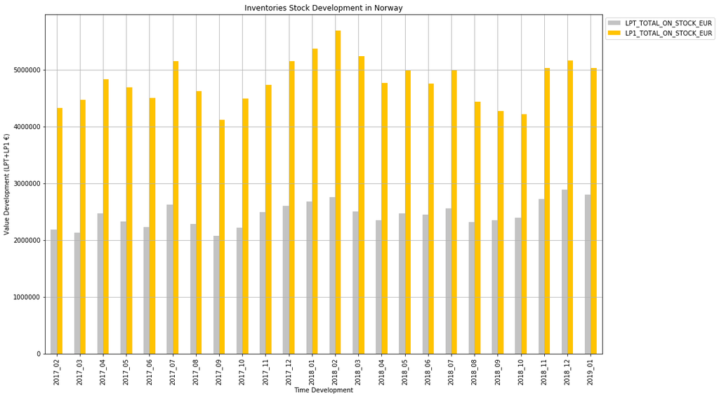

```python
C1 = Source[["CALMONTH", "LPT_TOTAL_ON_STOCK_EUR" , "LP1_TOTAL_ON_STOCK_EUR"]].groupby("CALMONTH", as_index=False).sum()
C1.plot.bar(x="CALMONTH",figsize=[16,10], grid=True, color = ["#C3C3C3","#FFC300"])

plt.title("Inventories Stock Development in %s"%(CountryName))
plt.xlabel("Time Development")
plt.ylabel("Value Development (LPT+LP1 €)")

plt.legend(loc="upper left", bbox_to_anchor=(1,1))
plt.show()
```

## 4.2 Produktgruppen Vergleich

Folgende Grafik soll im diesem Abschnittt erstellt werden:

- Vergleich zwischen Lagerbestandsreichweiten As-Is und Lagerbestandsreichweiten Optimum QTY
- Gesplittet nach Produktgruppen
- die Verteilung der Lagerreichweiten dargestellt in nebeneinander liegenden Boxplots

Dazu wird, nach bereits erfolgter Aktivierung des Python-Paketes "Seaborn", zunächst der Visualisierungsstil innerhalb Seaborn definiertund dieGröße des resultierenden Plots festgelegt:

```python
sns.set(style="whitegrid")
sns.set(rc={'figure.figsize':(16,9)})
```

Da für diese Auswertung der aktuellste Monat nur relevant ist, wird der Datensatz nach dem aktuellsten Rang gefiltert:

```python
C3 = Source[Source.RANG == 24]
```

Die Dummycodierungen (negativen Werte aus der Berechnung von oben) würden das Ergebnis der Visualisierung verfälschen und werden ebenfalls ausgefiltert:

```python
C3 = C3[C3.InvCov_As_Is >= 0]
```

Anschliesend werden die für diese Auswertung relevanten Spalten selektiert und die Werte aufsteigend nach Produktgruppe sortiert.

```python
C3 = C3[["PG","InvCov_As_Is", "InvCov_acc._Optimum QTY"]]
C3 = C3.sort_values(by=['PG'])
```

Im folgenden Befehl wird festgelegt, dass

- zwei nebeneinander liegende Plots erstellt werden sollen
- der gesamte Plot einen Titel besitzen soll
- und die beiden untergeordneten Plots mit den Werten aus dem oben erstellten Dataframe gespeist werden sollen:

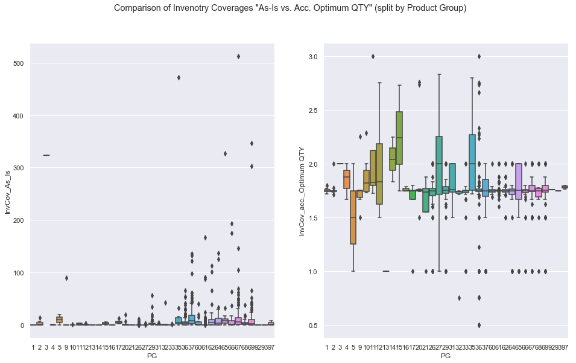

```python
f, axes = plt.subplots(1, 2)
f.suptitle('Comparison of Invenotry Coverages "As-Is vs. Acc. Optimum QTY" (split by Product Group)')

A = sns.boxplot(x="PG", y="InvCov_As_Is", data=C3, width=0.9, ax=axes[0])
B = sns.boxplot(x="PG", y="InvCov_acc._Optimum QTY", data=C3, width=0.9, ax=axes[1])
```

Das Ergebnis liefert 2 Boxplot Charts, die noch angepasst werden sollen:

Zunächst soll die Anzahl an Werten für der X-Achse limitiert werden. Daher wird festgelegt, dass im Ergebnischart maximal die TOP15 Produktgruppen angezeigt werden sollen.

Diese Top15 soll nach aktuellem Warenwert (LPT) auf Lager pro Produktgruppe selektiert werden. Zur visuellen Veranschaulichung liefert folgender Befehl die Grafik aller Produktgruppen nach Wert gebündelt zum heutigen Zeitpunkt:

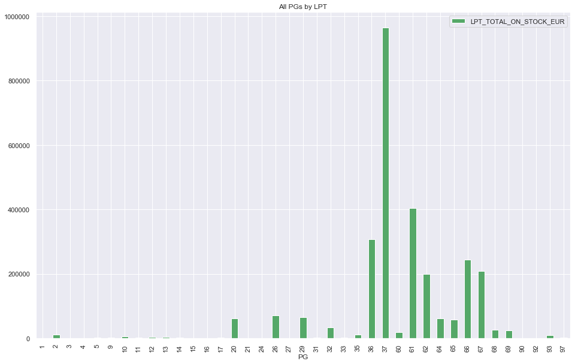

```python
C3_1 = Source[Source.RANG == 24]
C3_1 = C3_1[["PG", "LPT_TOTAL_ON_STOCK_EUR"]].groupby("PG", as_index=False).sum()
C3_1.plot.bar(x="PG",figsize=[16,10], grid=True, color = "g")
plt.title("All PGs by LPT")
```

Es sollen also die größten 15 (grünen) Balken der obigen Grafik für den finalen Boxplot-Vergleich angezogen werden.

Der folgende Befehl sortiert den vorher erzeugten Dataframe absteigend nach LPT-Wert und lässt in der zweiten Zeile nur die Werte in den Zeilen 0-14 (also die TOP15 Werte) über:

```python
C3_1 = C3_1.sort_values(by=['LPT_TOTAL_ON_STOCK_EUR'], ascending = False)
C3_1 = C3_1[:15]
```

Zur Kontrolle werden diese 15 Produktgruppen abermals visualisiert:

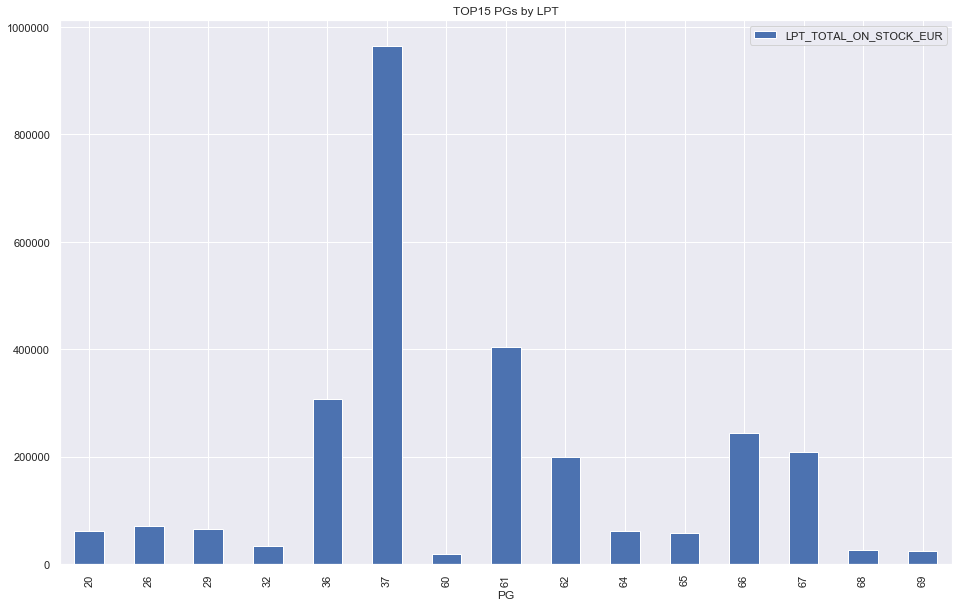

```python
C3_1 = C3_1[["PG", "LPT_TOTAL_ON_STOCK_EUR"]].groupby("PG", as_index=False).sum()
C3_1.plot.bar(x="PG",figsize=[16,10], grid=True, color = "b")
plt.title("TOP15 PGs by LPT")
```

Anschließend wird eine Liste aus den PG-Werten gebildet:

```python
TOP15 = [i for i in C3_1.PG]
print(TOP15)
```

```
[20, 26, 29, 32, 36, 37, 60, 61, 62, 64, 65, 66, 67, 68, 69]
```

Diese Werte können nun dem erstellten Dataframe mit dem Namen "C3" übergeben werden. Der Datensatz wird also auf die Werte der TOP15-Liste gefiltert.

```python
C3 = C3[C3["PG"].isin(TOP15)]
```

Die beiden Vergleichs-Boxplots können nochmals erstellt werden:

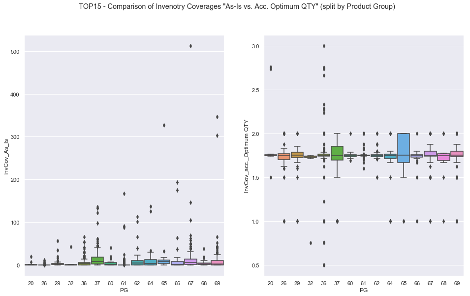

```python
f, axes = plt.subplots(1, 2)
f.suptitle('TOP15 - Comparison of Invenotry Coverages "As-Is vs. Acc. Optimum QTY" (split by Product Group)')

A = sns.boxplot(x="PG", y="InvCov_As_Is", data=C3, width=0.9, ax=axes[0])
B = sns.boxplot(x="PG", y="InvCov_acc._Optimum QTY", data=C3, width=0.9, ax=axes[1])
```

In einem weiteren Schritt können falls nötig Produktgruppen manuell ausgefiltert werden. Dieses vorgehen, kann beispielsweise bei landesspezifischen Produktgruppen sinnvoll sein.

In folgendem Befehl werden exemplarisch die Produktgruppen 67 und 69 manuell aussortiert und der bereits oben vorgestellte Befehl zum erstellen der Boxplots ausgeführt:

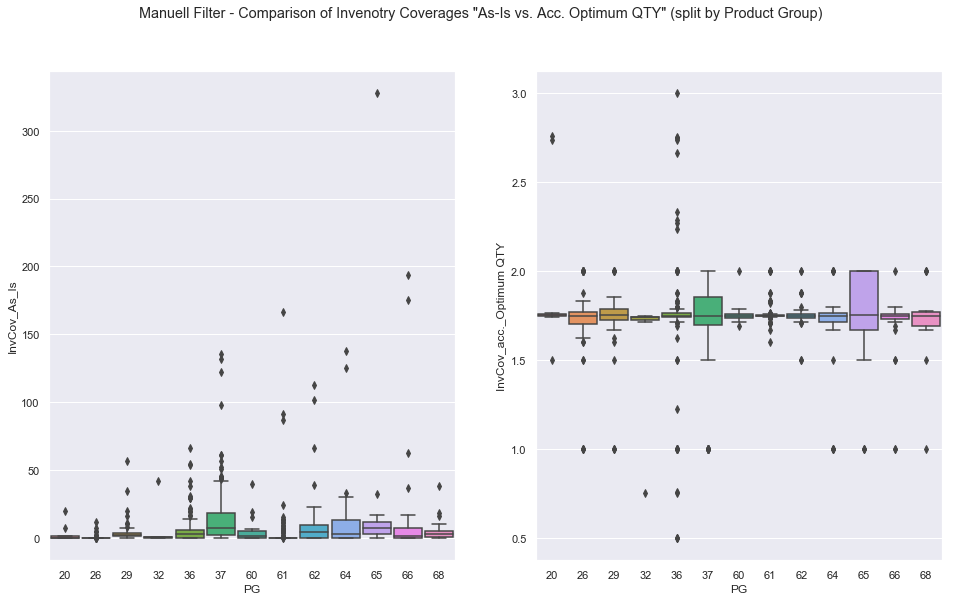

```python
y = [67,69]
x = [i for i in TOP15 if i not in y]
C3 = C3[C3["PG"].isin(x)]
f, axes = plt.subplots(1, 2)
f.suptitle('Manuell Filter - Comparison of Invenotry Coverages "As-Is vs. Acc. Optimum QTY" (split by Product Group)')

A = sns.boxplot(x="PG", y="InvCov_As_Is", data=C3, width=0.9, ax=axes[0])
B = sns.boxplot(x="PG", y="InvCov_acc._Optimum QTY", data=C3, width=0.9, ax=axes[1])
```

Das Ergebnis dieser Visualisierung zeigt folgendes auf:

Auf der As-Is Seite (links) ist gut zu erkennen, wie die Verteilung der Lagerreichweite mit sämtlichen Ausreisern heute aussieht.

Auf der Soll Seite (rechts) erkennt man, wie der Algorithmus Ausreiser im Bestand abfängt und je nach Nachfrage in verschiedene Artikelspezifische Lagerreichweiten einteilt.

An dieser Stelle sei nochmals angemerkt, dass die Lagerreichweite stehts der im Algorithmus definierten Wiederbeschaffungszeit entspricht, welche wie grafisch zu erkennen nie größer als 3 Monate im Sollzustand ist.

## 4.3 Lagerreichweiten auf Artikelebene

In der hier folgenden Darstellung soll ein zweites mal die Lagerreichweite der beiden Szenarien verglichen werden. Dabei soll die Produktgruppeneinteilung nicht berücksichtigt werden und ein Histogram über alle Artikel erstellt werden. Ziel ist es, aus einer anderen Betrachtungsweise als im vorigen Abschnitt aufzuzeigen, wie der Algorithmus die Bestände auf eine bestimmte Lagerreichweiten anpasst.

Wie schon im vorangegangenen Code wird zunächst ein neuer Dataframe erstellt, bei dem aus der Quelldatei veraltete Monatsränge und negative Lagerreichweiten (Sonderfälle) aussortiert werden. Anschließend erfolgt die Selektion auf die zwei relevanten Spalten des erstellten Dataframes:

```python
C2 = Source[Source.RANG == 24]
C2 = C2[C2.InvCov_As_Is >= 0]
C2 = C2[["InvCov_As_Is", "InvCov_acc._Optimum QTY"]]
```

Direkt im Anschluss wird ein transparentes Histogram erstellt, in der die x-Achse auf 50 (Monate) festgesetz wird. Die Anzahl der Säulen (= Bins) wird auf 200 eingestellt, da dann jede Säule den Häufigkeiten der Lieferzeiten in **Wochen** entspricht.

Ein dynamischer Titel gibt Aussage über den Inhalt des Histograms. Die übrigen Codezeilen erklären sich selbst:

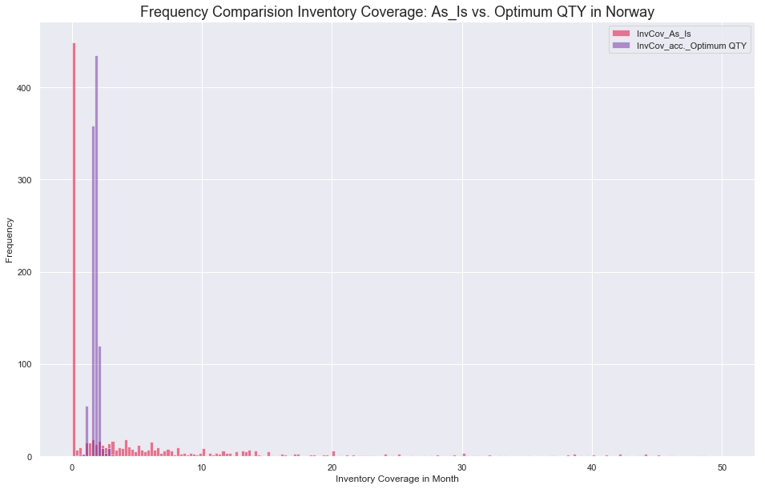

```python
C2.plot.hist(bins = 200, alpha=0.5, range=[0,50],figsize=[16,10],grid=True,color = ["#DC0032","#7030A0"])

plt.title("Frequency Comparision Inventory Coverage: As_Is vs. Optimum QTY in %s"%(CountryName), size=18)
plt.xlabel("Inventory Coverage in Month", size=12)
plt.ylabel("Frequency", size=12)
plt.legend(loc="best", bbox_to_anchor=(1,1))
```

Im Ergebnis ist abzulesen, dass die Verteilung der As-Is Coverages rechtsschief ist und der häufigste Wert bei einer Lagerreichweite von 0 Wochen liegt.

Weiterhin ist zu erkennen, dass der Optimum Quantity Algorithmus diesen Misssmatch korrigiert. Er baut für die kurzen Lagerbestandsreichweiten im As-Is Zustand Besände auf und spricht bei langen Lagerbestandsreichweiten Empfehlungen zur Bestandsreduktion aus. Der Hochpuknt dieser Neuverteilung liegt dabei bei 7-8 Wochen. Dieser Zeitraum wird wohl benötigt, um die meisten Artikel nachzuproduziern und nach Norwegen zu liefern.

## 4.4 Artikelebene - Focus on Low Hanging Fruits

Ziel des Inventory-Calculator-Projekts ist es Transparenz in den PERI Beständen zu schaffen. Dabei soll neben der Gesamtportfolioübersicht auf Einzelartikel eingegangen werden. Folgender Code berechnet, wieviele Einzelartikel im Datensatz der PERI Gruppe enthalten sind:

```python
Anz = Source[Source.RANG == 24]
print("Number of different articles in current portfolio: " + str(len(Anz["ARTICLE"]))+" articles")
```

```
Number of different articles in current portfolio: 1472 articles
```

Bei 1472 verschiedenen Artikeln ist es unerlässlich eine Priorisierung der Artikel vorzunehmen. Man könnte sich also im ersten Schritt auf wenige kapitalintensive Artikel in der Übermenge beschränken und hierfür eine Lösung finden. Später kann man die weniger hoch priorisierten Artikel nach selbiger Logik abarbeiten.

Um eine Übersicht über die Spalten des "Source"-Dataframes zu bekommen, werden die Kopfzeilen zunächst angezeigt. Dannach kann entschieden werden, welche Spalte für die Priorisierung genutzt wird.

```python
Source.columns
```

```
Index(['Custom_ID', 'Country', 'PSD_FA', 'STOCKYARD', 'CALMONTH', 'RANG',
       'ARTICLE', 'ARTICLE_TXT', 'PG', 'PG_TXT', 'REVENUE_FLAG', 'BASE_UOM',
       'PRICE_UNIT', 'HPC_PER_ARTICLE_EUR', 'NBV_PER_ARTICLE_EUR',
       'LPT_PER_ARTICLE_EUR', 'LP1_PER_ARTICLE_EUR', 'HPC_TOTAL_ON_STOCK_EUR',
       'NBV_TOTAL_ON_STOCK_EUR', 'LPT_TOTAL_ON_STOCK_EUR',
       'LP1_TOTAL_ON_STOCK_EUR', 'DISPOSALS_SALES', 'DISPOSALS_RENTAL_PARK',
       'DISPOSALS_S2S', 'DISPOSALS_OTHERS', 'ADDITIONS_S2S',
       'ADDITIONS_OTHERS', 'QTYSTOCK_LAST_DAY', 'TURNOVER_EUR',
       'NUMBER_OF_MAINORDERS', 'DisposalsTotal', 'AvgDisposalsPerMonthPCS',
       'AvgDisposalsPerMonthLP1', 'OptimumQTYPCS', 'OvercapacitiesPCS',
       'UndercapacitiesPCS', 'OvercapacitiesLP1', 'UndercapacitiesLP1',
       'OptimumQTY_LP1', 'InvCov_Prefilter', 'InvCov_As_Is',
       'InvCov_acc._Optimum QTY', 'Delta_of_both_InvCov'],
      dtype='object')
```

Nach dem die Dataframespalten durchgegangen wurden, wird entschieden die Priorisierung in Bezug auf Überkapazitäten basiernd der Spalte "OvercapacitiesLP1" vorzunehmen. Zum Fokus auf die höchsten Überkapazitäten, sollen nur die TOP10 Artikel der Überkapazitäten betrachtet werden.

Dazu wird der Datensatz nach dem aktuellen Rang (=aktuellstes Datum) gefiltert und über den anschließenden Befehl die zehn größten Werte der ausgewählten Spalte gesucht.

Im folgenden werden die TOP10 Artikel ausgegeben, welche die größten Überkapazitäten haben:

```python
TOP10_Overcapacities = Source[Source.RANG == 24]
TOP10_Overcapacities = TOP10_Overcapacities.nlargest(10, "OvercapacitiesLP1")
```

Anschließend werden die Artikelnummern aus der Spalte in eine Liste umgewandelt und das Ergebnis angezeigt:

```python
List_TOP10_Overcapacities = TOP10_Overcapacities.ARTICLE.values.tolist()
print("TOP10 Overcapacity Articles are: ",List_TOP10_Overcapacities)
```

```
TOP10 Overcapacity Articles are:  [130274, 130272, 202351, 202353, 131709, 116841, 200349, 200748, 202468, 123695]
```

Durch den folgenden Code hat der User die Möglichkeit einen bestimmter Artikel aus der TOP10 Liste zu wählen und die Artikelnummer in den Zwischenspeicher zu legen:

```python
Eingabe = int(input("Enter any article out of the TOP10 overcapacity list? "))
```

```
Enter any article out of the TOP10 overcapacity list? 130274
```

Schließlich wird der Bestandsverlauf der getätigten Eingabe visualisiert:

Um die Zeithistorie im Diagramm chronologisch aufzubauen, ist es dabei wichtig den Datensatz nach "RANG" zu sortieren.

```python
C4 = Source[Source.ARTICLE == Eingabe].sort_values(by="RANG", ascending=True)
```

Der Artikelname wird aus der anschließenden Codezeile ausgelesen:

```python
 ArticleName = C4.iloc[0,7]
```

Um eine Darstellung zu erhalten, die sämtliche relevanten Spalten beinhaltet, werden dabei drei Plotbefehle übereinander gelegt.

Die erste Codezeile erstellt ein Liniendiagramm mit den Bestandsverläufen As-Is und Optimum QTY. Die beiden darauffolgenden Zeilen legen dahinter eine Darstellung der Zu- und Abgänge im jeweiligen Zeitraum in Form zweier Säulendiagramme.

Als Diagramm Titel wird eine Kombination zwischen statischem Text und dynamischem Artikelnamen gewählt.

Die getätigte Eingabe kann geplottet werden:

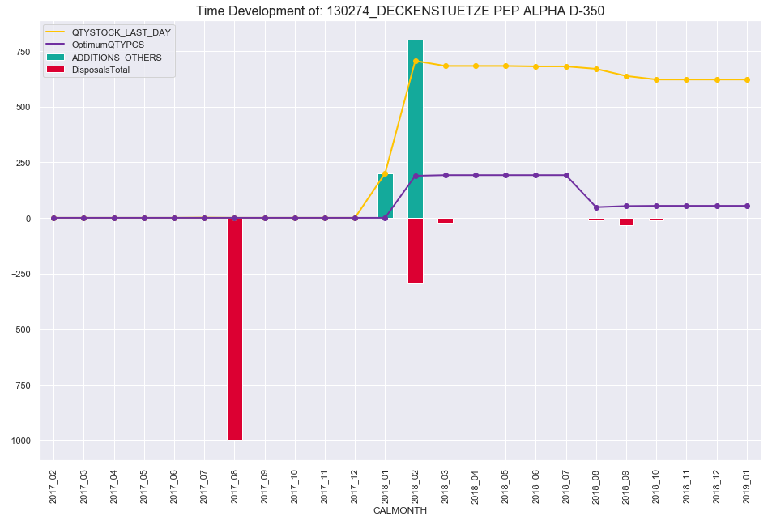

```python
ax = C4.plot(x='CALMONTH', y=["QTYSTOCK_LAST_DAY", "OptimumQTYPCS"], kind="line", marker='o', figsize=[16,10], color = ["#FFC300","#7030A0"], linewidth=2)
C4.plot(x='CALMONTH', y= 'ADDITIONS_OTHERS', color = "#14AA9B", kind="bar", ax=ax)
C4.plot(x='CALMONTH', y= "DisposalsTotal", color = "#DC0032", kind="bar", ax=ax)
plt.title("Time Development of: %s"%(ArticleName), size=16)
```

Aus der Darstellung wird ersichtlich, wie die Bestandsentwicklung des gewählten Artikels aussah, zu welchem Zeitpunkt der Artikel aus der Produktion Zugänge erfahren hat und wann der Artikel an Kunden verkauft wurde. Aus dieser Information können nun Entscheidungen des Managements getroffen werden, Bestände zu optimieren.

Durch Eingabe der nächsten Artikelnummer in obigem Eingabefeld könnte so die TOP10 Liste abgearbeitet werden.

## 5. Fazit

Im hier durchgeführten Projekt wurden verschiedene Datensätze eingelesen, darauf aufbauend Berechnungen durchgeführt und die Ergebnisse aus verschiedenen Blickrichtungen visualisiert.

Bisher werden vergleichbare Analysen bei PERI mit manuellen Datenuploads in Microsoft Excel und VBA durchgeführt.

Dabei ist die Performance, die MS Excel und Python liefern nicht zu vergleichen. Die Erfahrungen im Projekt haben eindrücklich gezeigt, dass Python um ein vielfaches schneller arbeitet und dabei signifikant stabiler läuft.

Zugegebenermaßen ist das coding mit Python anfangs zeitaufwändig: Man muss zunächst mit der neuen Syntax und den neuen Coding-Strukturen in Python vertraut werden. Allwerdings kann sich dieser Aufwand bereits nach kurzer Zeit durch oben genannte Performance Vorteile rechnen.

Zudem können sich neue Möglichkeiten ergeben, an welche bisher gar nicht gedacht wurde. Hier wäre die Möglichkeit zur automatisierten Datenanbindung an PERI-Quellysteme exemplarisch zu nennen, welcher in Excel nicht oder zumindest nur bedingt umsetzbar ist.

Zu klären ist jedoch, wie der Inventory Calculaor in Python operationalisiert werden kann: Das Tool sollte im Endzustand in der PERI Gruppe an rund 100 operative Mitarbeiter ausgerollt werden.